# Density models (gm, nc) → the merged species surface

Transforms onto the [0,100] scale, mosaic rules against AquaMaps/AquaX, and what each does to the scores

Published

2026-09-24

> **Not a pipeline stage** — an evaluation workbook rendered from the v9 build (`dist/`, `mc_parts/`, `merge.duckdb`, `sdm.duckdb`) plus the raw density sources, to settle *how* the two density-response datasets should enter the merge before any release does it. Everything it computes is reproducible from `quarto render compare_density_methods.qmd` (the derived density surfaces and per-method merges are cached under `marine-atlas/density_eval/`; `REDO_DENSITY=1` / `REDO_DENSITY_MERGE=1` rebuild them). The transforms are `msens::density_to_suit()` and the annual mean is `msens::density_annual()` — both unit-tested in `test-density.R` — so the ingest that eventually adopts one calls the same code this page evaluated.

## 1 Why this page exists

Two ingested datasets respond in **density** (individuals km<sup>-2</sup>), not habitat suitability:

- **`gm`** — NOAA SEFSC Gulf of America cetacean and sea-turtle spatial density models (Litz et al. 2022; Garrison et al. 2023; Rappucci et al. 2023): 19 monthly GAM/distance-sampling surfaces on a 40 km² hexagon grid (2003–2019 line-transect surveys, predictions on 2015–2019 monthly oceanography).
- **`nc`** — NOAA NCCOS at-sea marine bird density models, Atlantic (Winship et al. 2018) and Pacific (Leirness et al. 2021): seasonal 2 km surfaces from decades of boat and aerial transects (boosted zero-inflated GAMs).

Both are registered, published natively and drawn in the species app, but since v8 the docs carry them as *“Registered but not scored”*: the merge takes one surface per taxon on AquaMaps’ relative suitability scale ([0,100]; `msens::merge_sql()`), and density has had no agreed mapping onto it. These are also, arguably, the highest-value inputs the atlas holds for the uses BOEM and NOAA care about most — survey-based density is what NMFS itself uses to estimate exposure and take for incidental-take authorizations (the 2026 Gulf geophysical-survey rule is built on exactly these SEFSC surfaces (National Marine Fisheries Service 2026); Atlantic authorizations use the Duke habitat-based models (Roberts et al. 2016; Roberts and Halpin 2022; National Marine Fisheries Service 2023b)).

The page then shows a few species from each dataset before and after inclusion under each method (§ Section 8), tabulates how the Program-Area, ecoregion and subregion scores move (§ Section 9), and closes with the caveats the literature raises and a recommendation (§ Section 12, § Section 13). Along the way it also audits the v8/v9 ingests themselves and finds two faults worth fixing regardless of the method chosen (§ Section 11).

## 2 Design

```
flowchart LR
  raw["raw sources<br/>gm hexagons (monthly)<br/>nc COGs (seasonal)"] --> grid["density on the 0.05° grid<br/>(all intervals; absent = 0)"]
  grid --> ann["annual mean<br/>msens::density_annual()"]
  ann --> tf["transform → [0,100]<br/>msens::density_to_suit()<br/>cap · log · ud · qmap"]
  mc["v9 merge inputs<br/>mc_parts (am/ax/ranges)"] --> mos["mosaic per taxon<br/>max | replace (supersede_sql)<br/>fit | dist (dps_sql)"]
  tf --> mos
  mos --> us["US surface per method<br/>(M0 = v9 reproduced, asserted)"]
  us --> sc["Δ extrisk_{cat} → ecoregion rescale<br/>→ composite → zones"]
  sc --> tbl["zone table by method<br/>+ species maps"]
```

```
flowchart LR
  raw["raw sources<br/>gm hexagons (monthly)<br/>nc COGs (seasonal)"] --> grid["density on the 0.05° grid<br/>(all intervals; absent = 0)"]
  grid --> ann["annual mean<br/>msens::density_annual()"]
  ann --> tf["transform → [0,100]<br/>msens::density_to_suit()<br/>cap · log · ud · qmap"]
  mc["v9 merge inputs<br/>mc_parts (am/ax/ranges)"] --> mos["mosaic per taxon<br/>max | replace (supersede_sql)<br/>fit | dist (dps_sql)"]
  tf --> mos
  mos --> us["US surface per method<br/>(M0 = v9 reproduced, asserted)"]
  us --> sc["Δ extrisk_{cat} → ecoregion rescale<br/>→ composite → zones"]
  sc --> tbl["zone table by method<br/>+ species maps"]
```

Figure 1: Raw density → grid → annual mean → transform → mosaic with the v9 merge inputs → re-score; every branch is compared against the v9 status quo reproduced from the same inputs

## 3 Setup

```r
librarian::shelf(arrow, DBI, dplyr, duckdb, fs, ggplot2, glue, here, knitr, logger, patchwork,
                 purrr, readr, readxl, rnaturalearth, scales, sf, stringr, terra, tibble, tidyr,
                 tidyterra, MarineSensitivity/msens, quiet = TRUE)
source(here("libs/paths.R")); source(here("libs/vars.R")); source(here("libs/duckdb_budget.R"))
options(readr.show_col_types = FALSE, scipen = 999, knitr.kable.NA = "")
sf_use_s2(FALSE)
# the transforms are msens functions (R/density.R, unit-tested in test-density.R); a stale library
# would run without them, so the version is asserted rather than assumed
stopifnot("msens >= 0.45.0 with density_to_suit() is required: devtools::install('../msens')" =
            packageVersion("msens") >= "0.45.0" && exists("density_to_suit", asNamespace("msens")))

dir_atlas    <- path.expand(glue("{dir_big_v}/marine-atlas"))
dir_dist     <- glue("{dir_atlas}/dist")
dir_parts    <- glue("{dir_atlas}/mc_parts")
merge_db     <- glue("{dir_atlas}/merge.duckdb")
dir_eval     <- glue("{dir_atlas}/density_eval"); dir_create(dir_eval)   # this notebook's cache; not a release artifact
redo_density <- .flag("REDO_DENSITY")         # re-derive the density surfaces from the raw sources
redo_merge   <- .flag("REDO_DENSITY_MERGE")   # re-run the per-method merges + rescoring
gm_shp_dir   <- path.expand(Sys.getenv("GM_SHP_DIR", unset = paste0(
  "~/My Drive/projects/msens/data/raw/ncei.noaa.gov - GoMex cetacean & sea turtle SDMs/0256800/2.2/",
  "data/0-data/NOAA_SEFSC_Cetacean_SeaTurtle_SDM_shapefiles")))
stopifnot(file_exists(sdm_db), file_exists(merge_db), dir_exists(dir_parts), file_exists(cellid_tif),
          dir_exists(glue("{dir_dist}/dataset=gm")), dir_exists(glue("{dir_dist}/dataset=nc")),
          "gm inputs: set GM_SHP_DIR to the SEFSC shapefile folder" = dir_exists(gm_shp_dir))

suit_ds   <- c("am", "ax")                      # v9 suitability datasets (merge_models.qmd)
suit_in   <- paste(sprintf("'%s'", suit_ds), collapse = ", ")
turtle_ds <- "rng_turtle_swot_dps"
ch_ds     <- c("ch_nmfs", "ch_fws", "ca_nmfs")
sp_cats   <- c("bird", "coral", "fish", "invertebrate", "mammal", "primary_producer", "turtle")

eval_db <- glue("{dir_eval}/eval.duckdb")
if (redo_merge && file_exists(eval_db)) file_delete(eval_db)
con <- dbConnect(duckdb(eval_db))
duckdb_tune(con, glue("{dir_eval}/duckdb_tmp"))
dbExecute(con, glue("ATTACH '{sdm_db}' AS sdm (READ_ONLY)"))
```

```
[1] 0
```

```r
dbExecute(con, glue("ATTACH '{merge_db}' AS mrg (READ_ONLY)"))
```

```
[1] 0
```

```r
dbExecute(con, glue("ATTACH '{path.expand(spp_db)}' AS spp (READ_ONLY)"))
```

```
[1] 0
```

```r
grid   <- msens::grid_spec_for("global05", cellid_tif)
land   <- ne_countries(scale = "medium", returnclass = "sf")
ply_pa <- read_sf(path.expand(glue("{dir_derived}/v2/ply_programareas_2026.gpkg")))
ply_er <- read_sf(path.expand(glue("{dir_derived}/v1/ply_ecoregions_2025.gpkg")))
```

## 4 Density on the grid, from the raw sources

Both ingests already wrote a `dist/dataset={gm,nc}` surface on the grid, but that surface is the *transformed* value (`cap`, see below) with cells below 1 dropped, and its annual layer averages only the intervals a cell was present in. To evaluate transforms the density itself is needed, over the whole model domain and every interval — so it is re-derived here from the raw sources, and the ingested surfaces are audited against it in § Section 11.

### 4.1 NCCOS seabirds (`nc`): seasonal 2 km COGs → cells

Each COG (band 1 = `n_per_km2`) is projected from its oblique-Mercator grid to a 0.02° geographic grid (bilinear) and *averaged* into the 0.05° cells — an area-weighted mean that conserves the model’s abundance rather than the point-sampling bilinear pull the ingest used. The two regions are spatially disjoint and are unioned per species.

```r
nc_models <- read_csv(here("data/nc_models.csv")) |> filter(var == "n_per_km2") |>
  transmute(region_ds = ds_key, region, sp_code, season)
nc_multi <- read_csv(here("data/sdm/derived/nc_pac_birds_dens/m_spp-multiple.csv"))$sp_code
nc_xw <- bind_rows(
  read_csv(here("data/sdm/derived/nc_atl_birds_dens/mw_spp.csv")),
  read_csv(here("data/sdm/derived/nc_pac_birds_dens/m_spp.csv")),
  read_csv(here("data/sdm/derived/nc_pac_birds_dens/m_spp-multiple.csv"))) |>
  transmute(sp_code, sp_common, sp_scientific, gbif_id = as.character(sp_id)) |>
  distinct(sp_code, .keep_all = TRUE)

f_nc <- glue("{dir_eval}/nc_cells.parquet")
if (redo_density || !file_exists(f_nc)) {
  t0 <- Sys.time()
  nc_cells <- pmap_dfr(nc_models, function(region_ds, region, sp_code, season) {
    f <- here(glue("data/sdm/raw/{region_ds}/{sp_code}_{season}.tif"))
    if (!file_exists(f)) return(NULL)
    r <- rast(f, lyrs = 1)                                               # n_per_km2 on 2 km pixels
    src_total <- as.numeric(global(r, "sum", na.rm = TRUE)) * prod(res(r)) / 1e6   # individuals
    p <- project(r, "EPSG:4326", method = "bilinear", res = 0.02)        # ~2 km, finer than the cell
    d <- msens::cells_from_raster(p, cellid_tif, method = "average", min_value = 0,
                                  zero_fill = FALSE, digits = 6)
    tibble(region, sp_code, season, cell_id = d$cell_id, dens = d$val, src_total = src_total)
  })
  write_parquet(nc_cells, f_nc)
  log_info("nc: {nrow(nc_cells)} model-cell rows from {nrow(nc_models)} COGs in ",
           "{round(as.numeric(Sys.time() - t0, units = 'mins'), 1)} min")
}
nc_cells <- read_parquet(f_nc)

# annual mean: the mean over the 4 seasons of the year, an UNMODELLED season counting as zero
# (NCCOS fits a season only where the species was sighted enough to model); the present-only mean
# the ingest used is kept beside it for the audit
nc_annual <- nc_cells |> group_by(sp_code, region) |>
  group_modify(~ density_annual(.x, n_intervals = 4)) |> ungroup() |>
  left_join(nc_cells |> group_by(sp_code, region, cell_id) |>
              summarise(dens_present = mean(dens), n_ssn = n(), .groups = "drop"),
            by = c("sp_code", "region", "cell_id"))
nc_dom <- nc_cells |> distinct(region, cell_id)

# mass conservation per (species, region, season): Σ cell density × ocean-cell area vs the COG's own
# integral; < 1 where the domain touches land cells the grid does not carry
duckdb_register(con, "nc_cells_r", nc_cells)
nc_mass <- dbGetQuery(con, "
  SELECT region, sp_code, season, any_value(src_total) AS src_total,
         sum(n.dens * c.area_km2) AS cell_total, count(*) AS n_cells
  FROM nc_cells_r n JOIN sdm.cell c USING (cell_id) GROUP BY 1, 2, 3") |>
  mutate(ratio = cell_total / src_total)
duckdb_unregister(con, "nc_cells_r")
kable(nc_mass |> group_by(region) |> summarise(n_models = n(), ratio_min = round(min(ratio), 3),
        ratio_median = round(median(ratio), 3), ratio_max = round(max(ratio), 3),
        cells_median = median(n_cells)),
      caption = "nc: abundance conserved from COG to grid (Σ density × area over ocean cells / the COG's own integral). Above 1 where a partly covered edge cell takes the mean of its covered part over its full area; below 1 where the domain touches land cells the grid does not carry")
```

nc: abundance conserved from COG to grid (Σ density × area over ocean cells / the COG’s own integral). Above 1 where a partly covered edge cell takes the mean of its covered part over its full area; below 1 where the domain touches land cells the grid does not carry

| region | n_models | ratio_min | ratio_median | ratio_max | cells_median |
| --- | --- | --- | --- | --- | --- |
| Atlantic | 140 | 1.001 | 1.017 | 1.410 | 54798 |
| Pacific | 135 | 0.993 | 1.008 | 1.308 | 51031 |

### 4.2 SEFSC Gulf cetaceans and turtles (`gm`): monthly 40 km² hexagons → cells

`{Mon}_n` is the number of animals per 40 km² hexagon (Litz et al. 2022), so density is `n / 40`; `-9999` marks a hexagon outside a model’s domain (a shelf model over oceanic water, and vice versa). The two split-population species (Atlantic spotted and common bottlenose dolphins, Oceanic + Shelf) are summed per hexagon. Each cell takes the hexagon under its centre — a 40 km² hexagon covers ~1.5 cells at this latitude, so no hexagon is skipped.

```r
gm_taxa  <- read_excel(glue("{gm_shp_dir}/../spp_gmx.xlsx")) |>
  select(taxa_shp, taxa_sci, taxa_common, taxa_doc)
gm_files <- tibble(path = dir_ls(gm_shp_dir, glob = "*.shp")) |>
  mutate(base       = path_ext_remove(path_file(path)),
         taxa_shp   = str_replace(base, "_Monthly_.*$", ""),
         population = if_else(str_detect(base, "^(Oceanic|Shelf)_"),
                              str_extract(base, "^(Oceanic|Shelf)"), NA_character_)) |>
  left_join(gm_taxa, by = "taxa_shp")
stopifnot("every gm shapefile resolves in spp_gmx.xlsx" = !any(is.na(gm_files$taxa_sci)))

f_gm <- glue("{dir_eval}/gm_cells.parquet"); f_gm_hex <- glue("{dir_eval}/gm_hex_months.parquet")
if (redo_density || !file_exists(f_gm)) {
  t0 <- Sys.time()
  r_gulf <- crop(rast(cellid_tif), ext(-98.5, -79.5, 17.5, 31.5))
  out <- list(); hexm <- list()
  for (sci in unique(gm_files$taxa_sci)) {
    fi <- gm_files |> filter(taxa_sci == sci)
    hx <- bind_rows(lapply(fi$path, function(p)
      read_sf(p) |> st_transform(4326) |> select(hexid = HEXID, any_of(paste0(month.abb, "_n")))))   # some surfaces carry fewer than 12 months
    long <- hx |> st_drop_geometry() |>
      pivot_longer(-hexid, names_to = "mo", values_to = "n") |>
      filter(n != -9999) |>
      mutate(mm = sprintf("%02d", match(str_remove(mo, "_n"), month.abb))) |>
      group_by(hexid, mm) |> summarise(n = sum(n), .groups = "drop")      # Oceanic + Shelf summed
    geoms <- hx[!duplicated(hx$hexid), "hexid"]
    r_hex <- rasterize(vect(geoms), r_gulf, field = "hexid")
    xw    <- as.data.frame(c(r_hex, r_gulf), na.rm = TRUE); names(xw) <- c("hexid", "cell_id")
    out[[sci]]  <- long |> inner_join(xw, by = "hexid", relationship = "many-to-many") |>
      transmute(taxa_sci = sci, mm, cell_id = as.integer(cell_id), dens = n / 40)   # individuals km^-2
    hexm[[sci]] <- long |> mutate(taxa_sci = sci)
  }
  write_parquet(bind_rows(out), f_gm); write_parquet(bind_rows(hexm), f_gm_hex)
  log_info("gm: {nrow(bind_rows(out))} model-cell rows from {nrow(gm_files)} shapefiles in ",
           "{round(as.numeric(Sys.time() - t0, units = 'mins'), 1)} min")
}
gm_cells <- read_parquet(f_gm); gm_hex <- read_parquet(f_gm_hex)

# annual mean over the months the taxon's MODEL provides (all 12 but for Kogia, Apr-Nov): a month the
# model does not cover is not a zero, while within a covered month a hexagon without a value is
# outside the domain (not a zero either -- the -9999 month inside a domain is rare, see the table)
gm_annual <- gm_cells |> group_by(taxa_sci) |>
  group_modify(~ density_annual(.x, n_intervals = n_distinct(.x$mm))) |> ungroup() |>
  left_join(gm_cells |> group_by(taxa_sci, cell_id) |>
              summarise(dens_present = mean(dens), n_mo = n(), .groups = "drop"),
            by = c("taxa_sci", "cell_id"))
gm_dom <- gm_cells |> distinct(cell_id)

# how complete is the monthly record per hexagon? (a -9999 month inside a model's domain is rare)
gm_months <- gm_hex |> count(taxa_sci, hexid, name = "n_mo") |>
  group_by(taxa_sci) |> summarise(n_hex = n(), pct_12_months = round(100 * mean(n_mo == 12), 1),
                                  months_median = median(n_mo), .groups = "drop")

# mass conservation per (taxon, month): Σ cell density × ocean-cell area vs Σ hexagon abundance
duckdb_register(con, "gm_cells_r", gm_cells)
duckdb_register(con, "gm_hex_r", gm_hex)
gm_share_usa <- dbGetQuery(con, "SELECT round(100.0 * count(*) FILTER (WHERE c.in_usa) / count(*), 1) AS pct
  FROM (SELECT DISTINCT cell_id FROM gm_cells_r) d JOIN sdm.cell c USING (cell_id)")$pct
gm_mass <- dbGetQuery(con, "
  WITH src AS (SELECT taxa_sci, mm, sum(n) AS src_total FROM gm_hex_r GROUP BY 1, 2),
       cel AS (SELECT g.taxa_sci, g.mm, sum(g.dens * c.area_km2) AS cell_total,
                      sum(g.dens * c.area_km2) FILTER (WHERE c.in_usa) AS cell_total_usa
               FROM gm_cells_r g JOIN sdm.cell c USING (cell_id) GROUP BY 1, 2)
  SELECT * FROM src JOIN cel USING (taxa_sci, mm)") |>
  mutate(ratio = cell_total / src_total, share_usa = cell_total_usa / cell_total)
duckdb_unregister(con, "gm_cells_r"); duckdb_unregister(con, "gm_hex_r")
kable(gm_mass |> group_by(taxa_sci) |> summarise(ratio_min = round(min(ratio), 3), ratio_median = round(median(ratio), 3),
        ratio_max = round(max(ratio), 3), share_usa = round(median(share_usa), 2), .groups = "drop") |>
        left_join(gm_months, by = "taxa_sci"),
      caption = glue("gm: abundance conserved from hexagons to grid (ratio), the share of each model's ",
                     "abundance inside the US study area (the rest is the extrapolation beyond US waters ",
                     "the dataset warns about; {gm_share_usa} % of the domain's ocean cells are in_usa), ",
                     "and the completeness of the monthly record per hexagon"))
```

gm: abundance conserved from hexagons to grid (ratio), the share of each model’s abundance inside the US study area (the rest is the extrapolation beyond US waters the dataset warns about; 46.2 % of the domain’s ocean cells are in_usa), and the completeness of the monthly record per hexagon

| taxa_sci | ratio_min | ratio_median | ratio_max | share_usa | n_hex | pct_12_months | months_median |
| --- | --- | --- | --- | --- | --- | --- | --- |
| Balaenoptera ricei | 0.952 | 0.957 | 0.960 | 0.75 | 33650 | 100.0 | 12 |
| Caretta caretta | 0.946 | 0.952 | 0.958 | 0.57 | 14293 | 100.0 | 12 |
| Chelonia mydas | 0.924 | 0.933 | 0.940 | 0.58 | 14293 | 100.0 | 12 |
| Delphinidae | 0.947 | 0.949 | 0.954 | 0.40 | 26532 | 100.0 | 12 |
| Dermochelys coriacea | 0.940 | 0.959 | 0.966 | 0.76 | 14195 | 99.9 | 12 |
| Globicephala | 0.943 | 0.945 | 0.949 | 0.35 | 26532 | 100.0 | 12 |
| Grampus griseus | 0.942 | 0.946 | 0.950 | 0.36 | 26532 | 100.0 | 12 |
| Kogia | 0.949 | 0.951 | 0.952 | 0.35 | 26486 | 0.0 | 8 |
| Lepidochelys kempii | 0.944 | 0.949 | 0.964 | 0.52 | 14293 | 100.0 | 12 |
| Physeter macrocephalus | 0.948 | 0.949 | 0.951 | 0.44 | 26486 | 100.0 | 12 |
| Stenella attenuata | 0.940 | 0.946 | 0.954 | 0.37 | 26532 | 100.0 | 12 |
| Stenella clymene | 0.932 | 0.939 | 0.942 | 0.18 | 26532 | 100.0 | 12 |
| Stenella coeruleoalba | 0.954 | 0.957 | 0.962 | 0.58 | 26532 | 100.0 | 12 |
| Stenella frontalis | 0.953 | 0.954 | 0.955 | 0.47 | 41052 | 100.0 | 12 |
| Stenella longirostris | 0.951 | 0.957 | 0.960 | 0.56 | 26532 | 100.0 | 12 |
| Tursiops truncatus | 0.942 | 0.947 | 0.955 | 0.62 | 41044 | 100.0 | 12 |
| Ziphius | 0.947 | 0.949 | 0.950 | 0.36 | 26486 | 100.0 | 12 |

## 5 Taxon crosswalk and eligibility

```r
# --- gm: WoRMS id from the ingest's registry; rank from the WoRMS snapshot flags the guilds
model_gm <- read_csv(glue("{dir_dist}/model_gm.csv")) |> filter(interval == "annual") |>
  transmute(sp_id, scientific_name)
gm_ids   <- str_remove(model_gm$sp_id, "^WORMS:")
worms_rank <- dbGetQuery(con, glue("SELECT CAST(scientificNameID AS VARCHAR) AS id, taxonRank AS rank
  FROM spp.worms WHERE scientificNameID IN ({paste(gm_ids, collapse = ',')})"))
gm_tx <- gm_files |>
  mutate(taxa_common = str_remove(taxa_common, "^(Oceanic|Shelf) ")) |>   # one taxon for a split-population pair
  distinct(taxa_sci, .keep_all = TRUE) |> select(taxa_sci, taxa_common, taxa_doc) |>
  left_join(model_gm, by = c("taxa_sci" = "scientific_name")) |>
  mutate(id = str_remove(sp_id, "^WORMS:")) |>
  left_join(worms_rank, by = "id") |>
  transmute(ds_key = "gm", sp_id, ingest_sp_id = sp_id, sp_label = taxa_sci, scientific_name = taxa_sci,
            common_name_src = taxa_common, is_guild = rank != "Species",
            guild_note = if_else(rank != "Species", str_remove(taxa_doc, ";$"), NA_character_),
            ms_merge_key = if_else(rank == "Species", paste0("ms_merge|", sp_id), NA_character_),
            match_by = if_else(rank == "Species", "worms id", NA_character_))

# --- nc: common name → BirdLife, then scientific name, then a curated override
bl <- read_csv(glue("{dir_dist}/model_bl.csv")) |>
  transmute(sisid = as.character(sisid), bl_sci = sci_name, bl_common = common)
norm <- function(x) str_to_lower(str_replace_all(x, "[^A-Za-z]", ""))
nc_override <- tribble(
  ~sp_code, ~sisid,     ~note,
  "HERG",   "62030590", "American herring gull = BirdLife Larus smithsonianus (the GBIF name L. argentatus is the European species)")
nc_tx <- nc_xw |> filter(sp_code %in% nc_models$sp_code) |>
  mutate(is_guild = sp_code %in% nc_multi | str_detect(sp_code, "-") | !str_detect(sp_scientific, " ") |
                    str_detect(sp_common, "spp\\.|/"),
         k_common = norm(sp_common), k_sci = norm(sp_scientific)) |>
  left_join(bl |> mutate(k_common = norm(bl_common)) |> select(k_common, sis_common = sisid), by = "k_common") |>
  left_join(bl |> mutate(k_sci = norm(bl_sci)) |> select(k_sci, sis_sci = sisid), by = "k_sci") |>
  left_join(nc_override, by = "sp_code") |>
  mutate(match_by = case_when(!is.na(sisid) ~ "override", !is.na(sis_common) ~ "common name",
                              !is.na(sis_sci) ~ "scientific name", TRUE ~ NA_character_),
         sisid = coalesce(sisid, sis_common, sis_sci)) |>
  left_join(bl, by = "sisid") |>
  transmute(ds_key = "nc", sp_id = sp_code, ingest_sp_id = gbif_id, sp_label = sp_code, scientific_name = sp_scientific,
            common_name_src = sp_common, is_guild,
            guild_note = if_else(is_guild, sp_common, NA_character_),
            ms_merge_key = if_else(!is_guild & !is.na(sisid), paste0("ms_merge|BOTW:", sisid), NA_character_),
            match_by = if_else(is_guild, NA_character_, match_by), gbif_id, sisid, bl_sci, bl_common, note)
write_csv(nc_tx |> select(sp_code = sp_id, sp_common = common_name_src, nc_scientific = scientific_name,
                          gbif_id, is_guild, match_by, sisid, botw_scientific = bl_sci,
                          botw_common = bl_common, ms_merge_key, note),
          here("data/nc_taxon_crosswalk.csv"), na = "")

# --- the atlas side: scoring attributes, merge id, input datasets
taxa0 <- bind_rows(gm_tx, nc_tx |> select(-gbif_id, -sisid, -bl_sci, -bl_common, -note))
duckdb_register(con, "taxa0", taxa0)
taxa <- dbGetQuery(con, "
  SELECT x.*, t.scientific_name AS atlas_name, t.common_name, t.sp_cat, t.extrisk_code, t.er_score,
         t.er_mode, t.is_valid_usa, t.is_marine, t.n_usa, m.mkey_id, f.has_range, f.has_suit,
         (SELECT string_agg(DISTINCT ds_key, ',' ORDER BY ds_key) FROM sdm.taxon_model tm
            WHERE tm.ms_merge_key = x.ms_merge_key) AS datasets
  FROM taxa0 x
  LEFT JOIN sdm.taxon t      ON t.ms_merge_key = x.ms_merge_key
  LEFT JOIN mrg.mkey_map m   ON m.ms_merge_key = x.ms_merge_key
  LEFT JOIN mrg.taxon_flags f ON f.ms_merge_key = x.ms_merge_key") |>
  mutate(eligible = !is_guild & !is.na(mkey_id) & coalesce(is_valid_usa, FALSE) & coalesce(is_marine, FALSE),
         status = case_when(is_guild ~ "guild / species group",
                            is.na(ms_merge_key) ~ "no BirdLife match",
                            is.na(mkey_id) ~ "not a v9 taxon",
                            !coalesce(is_valid_usa, FALSE) ~ "not valid in US",
                            !coalesce(is_marine, FALSE) ~ "culled as non-marine",
                            TRUE ~ "eligible")) |>
  arrange(ds_key, scientific_name)
duckdb_unregister(con, "taxa0")
# the NMFS-DPS taxa merge through dps_sql() with a per-cell ER; none of these should be one
stopifnot("a density taxon is also an NMFS-DPS taxon (er_mode = 'cell'): extend the dist branch first" =
            !any(taxa$er_mode[taxa$eligible] == "cell", na.rm = TRUE))

kable(taxa |> count(ds_key, status) |> pivot_wider(names_from = ds_key, values_from = n, values_fill = 0),
      caption = "Density-model taxa by dataset and eligibility for the fold-in")
```

Density-model taxa by dataset and eligibility for the fold-in

| status | gm | nc |
| --- | --- | --- |
| eligible | 13 | 68 |
| guild / species group | 4 | 13 |
| not valid in US | 0 | 1 |

```r
kable(taxa |> filter(!eligible) |> select(ds_key, sp_label, scientific_name, atlas_name, status, guild_note, datasets),
      caption = "The taxa that cannot fold in as they stand — a species group needs an attribution rule (exclude, share, or duplicate across members); an unmatched name needs a crosswalk row")
```

The taxa that cannot fold in as they stand — a species group needs an attribution rule (exclude, share, or duplicate across members); an unmatched name needs a crosswalk row

| ds_key | sp_label | scientific_name | atlas_name | status | guild_note | datasets |
| --- | --- | --- | --- | --- | --- | --- |
| gm | Delphinidae | Delphinidae |  | guild / species group | Blackfish (Orcinus orca, Peponocephala electra, Feresa attenuata and Pseudorca crassidens combined) |  |
| gm | Globicephala | Globicephala |  | guild / species group | Pilot whales (Globicephala sp.) |  |
| gm | Kogia | Kogia |  | guild / species group | Pygmy or Dwarf sperm whales (Kogia spp.) |  |
| gm | Ziphius | Ziphius |  | guild / species group | Beaked whales (Ziphius and Mesoplodon spp.) |  |
| nc | WEGR-CLGR | Aechmophorus clarkii |  | guild / species group | Western/Clark’s Grebe |  |
| nc | STTS-SOSH-FFSH | Ardenna carneipes |  | guild / species group | Short-tailed/Sooty/Flesh-footed Shearwater |  |
| nc | COSH | Calonectris diomedea | Calonectris borealis | not valid in US |  | bl |
| nc | LOON | Gavia |  | guild / species group | Loon spp. |  |
| nc | HERG-ICGU | Larus argentatus |  | guild / species group | Herring/Iceland Gull |  |
| nc | WEGU-WGWH-GWGU | Larus glaucescens |  | guild / species group | Western/Glaucous-winged Gull |  |
| nc | SCOT | Melanitta |  | guild / species group | Scoter spp. |  |
| nc | CORM | Phalacrocorax |  | guild / species group | Cormorant spp. |  |
| nc | PHAL | Phalaropus |  | guild / species group | Phalarope spp. |  |
| nc | JAEG | Stercorarius longicaudus |  | guild / species group | Jaeger spp. |  |
| nc | PAJA-LTJA | Stercorarius longicaudus |  | guild / species group | Parasitic/Long-tailed Jaeger |  |
| nc | COTE-ARTE | Sterna hirundo |  | guild / species group | Common/Arctic Tern |  |
| nc | SCMU-GUMU-CRMU | Synthliboramphus craveri |  | guild / species group | Scripps’s/Guadalupe/Craveri’s Murrelet |  |
| nc | ROYT-ELTE | Thalasseus elegans |  | guild / species group | Royal/Elegant Tern |  |

```r
tx <- taxa |> filter(eligible)
kable(tx |> transmute(ds_key, sp_label, atlas_name, common_name, sp_cat, extrisk_code, er_score, er_mode,
                      datasets, n_usa, match_by),
      caption = "Eligible taxa: the v9 governing extinction-risk score (er_score; MMPA floor 20 for marine mammals, MBTA floor 10 for birds), how their ER enters the score (er_mode), and the datasets already feeding their merged surface")
```

Eligible taxa: the v9 governing extinction-risk score (er_score; MMPA floor 20 for marine mammals, MBTA floor 10 for birds), how their ER enters the score (er_mode), and the datasets already feeding their merged surface

[output not shown]

[output cut: 51 more lines]

## 6 Methods

### 6.1 Transforms onto [0,100]

Four monotone transforms of the annual mean density, all from `msens::density_to_suit()`:

| transform | rule | keeps | precedent |
| --- | --- | --- | --- |
| **cap** | `100 · min(d / q₀.₉₉₅, 1)` — linear, 100 at the 99.5th percentile of positive density | proportionality: Σ val ∝ abundance below the cap | the v8 ingests; percentile ceilings in cumulative-impact mapping (Halpern et al. 2019) |
| **log** | linear in log d between the 1st and 99.5th percentiles | the ordering; compresses the tail | `ln(density)` before combining species (Bradbury et al. 2014); `log(x+1)` then rescale (Halpern et al. 2015) |
| **ud** | 100 − % of the modelled population in cells strictly denser than this one | the population percentile: `val ≥ 100 − p` is exactly the p % core | utilization-distribution isopleths (Fieberg and Kochanny 2005; Laver and Kelly 2008); MDAT’s 50 % cumulative-abundance core areas on these same Duke/NCCOS surfaces (Curtice et al. 2019); percentile ra… |
| **qmap** | quantile-map the density distribution onto the taxon’s own AquaMaps/AquaX values over the same cells | the ordering *and* the incumbent’s marginal, so the fold-in redistributes rather than re-levels | quantile mapping / histogram matching (Cannon, Sobie, and Murdock 2015; Gudmundsson et al. 2012), with its known limits (Maraun 2016, 2013) |

`qmap` needs an incumbent suitability surface inside the domain. All 13 species-level `gm` taxa have one (AquaMaps and AquaX); the `nc` birds have none — the atlas’ bird surfaces are BirdLife ranges valued at the MBTA floor — so for them `qmap` falls back to `cap` and the table says so. The transforms are computed over each model’s **domain**: for `nc` every modelled cell, for `gm` the modelled hexagons inside the US study area (the dataset’s own metadata warns that its extrapolation beyond US waters should be “interpreted with caution”).

```r
# density per eligible taxon on the grid's ocean cells (the merge and the score never see land
# cells); gm restricted to in_usa, nc to its modelled cells
dens_tx <- bind_rows(
  gm_annual |> inner_join(tx |> filter(ds_key == "gm") |> select(taxa_sci = scientific_name, ms_merge_key), by = "taxa_sci") |>
    transmute(ms_merge_key, ds_key = "gm", cell_id, dens),
  nc_annual |> inner_join(tx |> filter(ds_key == "nc") |> select(sp_code = sp_id, ms_merge_key), by = "sp_code") |>
    transmute(ms_merge_key, ds_key = "nc", cell_id, dens))
duckdb_register(con, "dens_tx_r", dens_tx)
dbExecute(con, "CREATE OR REPLACE TABLE dens AS
  SELECT d.ms_merge_key, d.ds_key, d.cell_id, d.dens, c.area_km2, c.in_usa
  FROM dens_tx_r d JOIN sdm.cell c USING (cell_id)
  WHERE d.ds_key = 'nc' OR c.in_usa")
```

```
[1] 4405303
```

```r
duckdb_unregister(con, "dens_tx_r")
dbExecute(con, "CREATE OR REPLACE TABLE tx_dom AS SELECT DISTINCT ms_merge_key, cell_id FROM dens")
```

```
[1] 4405303
```

```r
dbExecute(con, "CREATE OR REPLACE TABLE us_cells AS SELECT cell_id FROM sdm.cell WHERE in_usa")
```

```
[1] 634208
```

```r
# the v9 merge inputs of these taxa (post-supersession: am is already gone inside the AquaX mask),
# trimmed to the US cells up front: every rule below is per cell and the surface compared is the
# US scoring surface, so the trim changes nothing and spares scanning the birds' global ranges
parts <- paste0("'", dir_parts, "/mkey_id=", tx$mkey_id, "/*.parquet'", collapse = ", ")
dbExecute(con, glue("CREATE OR REPLACE TABLE inputs AS
  SELECT i.ms_merge_key, i.ds_key, i.cell_id, i.val
  FROM read_parquet([{parts}], hive_partitioning = true) i JOIN us_cells u USING (cell_id)"))
```

```
[1] 15885482
```

```r
dbExecute(con, glue("CREATE OR REPLACE TABLE taxon AS
  SELECT ms_merge_key, er_score FROM sdm.taxon WHERE ms_merge_key IN ({paste(sprintf(\"'%s'\", tx$ms_merge_key), collapse = ',')})"))
```

```
[1] 81
```

```r
dbExecute(con, glue("CREATE OR REPLACE TABLE taxon_flags AS
  SELECT * FROM mrg.taxon_flags WHERE ms_merge_key IN ({paste(sprintf(\"'%s'\", tx$ms_merge_key), collapse = ',')})"))
```

```
[1] 81
```

```r
# reference distribution for qmap: the taxon's own suitability inside its domain
ref_df  <- dbGetQuery(con, glue("SELECT i.ms_merge_key, i.cell_id, max(i.val) AS val
  FROM inputs i JOIN tx_dom t USING (ms_merge_key, cell_id) WHERE i.ds_key IN ({suit_in}) GROUP BY 1, 2"))
dens_df <- dbGetQuery(con, "SELECT ms_merge_key, ds_key, cell_id, dens, area_km2 FROM dens ORDER BY 1, 3")
transforms <- c("cap", "log", "ud", "qmap")
tf <- dens_df |> group_by(ms_merge_key, ds_key) |>
  group_modify(function(x, k) {
    ref   <- ref_df$val[ref_df$ms_merge_key == k$ms_merge_key]
    qm_ok <- length(ref) >= 100
    bind_rows(lapply(transforms, function(m) tibble(
      cell_id = x$cell_id, transform = m,
      val = switch(m,
        cap  = density_to_suit(x$dens, "cap"),
        log  = density_to_suit(x$dens, "log"),
        ud   = density_to_suit(x$dens, "ud", area = x$area_km2),
        qmap = if (qm_ok) density_to_suit(x$dens, "qmap", ref = ref) else density_to_suit(x$dens, "cap")),
      qmap_ref_n = length(ref))))
  }) |> ungroup() |> filter(val > 0)
duckdb_register(con, "tf_r", tf)
dbExecute(con, "CREATE OR REPLACE TABLE dens_suit AS SELECT ms_merge_key, ds_key, cell_id, transform, val FROM tf_r")
```

```
[1] 17391395
```

```r
duckdb_unregister(con, "tf_r")

# per-taxon transform diagnostics
tf_diag <- tf |> group_by(ms_merge_key, transform) |>
  summarise(n = n(), mean_val = round(mean(val), 1), median_val = round(median(val), 1),
            pct_ge50 = round(100 * mean(val >= 50), 1), qmap_ref_n = first(qmap_ref_n), .groups = "drop") |>
  left_join(tx |> select(ms_merge_key, ds_key, sp_label, common_name), by = "ms_merge_key")
kable(tf_diag |> group_by(ds_key, transform) |>
        summarise(taxa = n(), mean_val = round(median(mean_val), 1), median_val = round(median(median_val), 1),
                  pct_ge50 = round(median(pct_ge50), 1), qmap_fallback = sum(qmap_ref_n < 100), .groups = "drop"),
      caption = "How each transform distributes a taxon's domain over [0,100] (medians across taxa of the per-taxon mean, median and share of cells ≥ 50); qmap_fallback = taxa with no incumbent suitability inside the domain, mapped with cap instead")
```

How each transform distributes a taxon’s domain over [0,100] (medians across taxa of the per-taxon mean, median and share of cells ≥ 50); qmap_fallback = taxa with no incumbent suitability inside the domain, mapped with cap instead

| ds_key | transform | taxa | mean_val | median_val | pct_ge50 | qmap_fallback |
| --- | --- | --- | --- | --- | --- | --- |
| gm | cap | 13 | 20.3 | 10.6 | 10.3 | 0 |
| gm | log | 13 | 57.2 | 57.6 | 63.0 | 0 |
| gm | qmap | 13 | 88.3 | 89.8 | 99.9 | 0 |
| gm | ud | 13 | 22.7 | 12.8 | 16.5 | 0 |
| nc | cap | 68 | 7.3 | 3.0 | 2.0 | 68 |
| nc | log | 68 | 31.1 | 28.1 | 16.2 | 68 |
| nc | qmap | 68 | 7.3 | 3.0 | 2.0 | 68 |
| nc | ud | 68 | 18.2 | 11.1 | 9.7 | 68 |

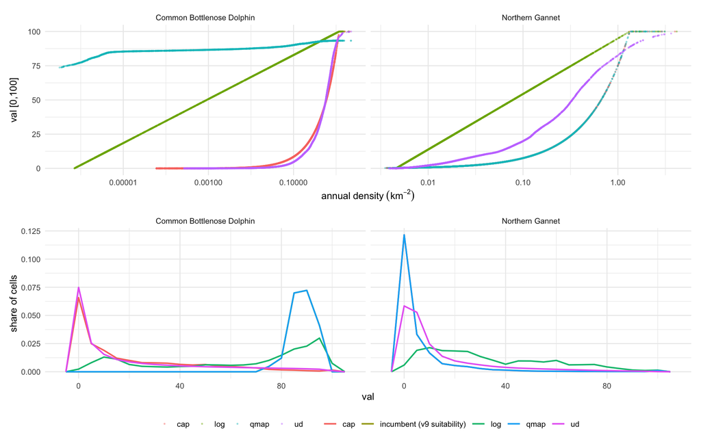

Figure 2: The four transforms on two species: value against annual density (log axis) and the resulting distribution of values across the domain, beside the incumbent v9 suitability at the same cells. cap keeps proportionality and leaves most cells low; ud is as bottom-heavy in cell counts (the population lives in few cells) but ranks the top cells by the share they hold; log alone spreads the bulk of the domain across the scale; qmap reproduces the incumbent’s marginal (AquaX paints the Gulf dolphins at a mean near 90). The gannet has no incumbent surface, so its qmap is cap.

```r
show <- tx |> filter(sp_label %in% c("Tursiops truncatus", "NOGA")) |> select(ms_merge_key, common_name)
pd <- tf |> inner_join(show, by = "ms_merge_key") |>
  inner_join(dens_df |> select(ms_merge_key, cell_id, dens), by = c("ms_merge_key", "cell_id"))
pr <- ref_df |> inner_join(show, by = "ms_merge_key") |> mutate(transform = "incumbent (v9 suitability)")
set.seed(1)
p1 <- ggplot(pd |> filter(dens > 0) |> group_by(common_name, transform) |> slice_sample(n = 4000) |> ungroup(),
             aes(dens, val, colour = transform)) +
  geom_point(size = 0.4, alpha = 0.35) +
  scale_x_log10(labels = label_number()) + facet_wrap(~ common_name, scales = "free_x") +
  labs(x = expression(annual~density~(km^-2)), y = "val [0,100]", colour = NULL) + theme_minimal()
p2 <- ggplot(bind_rows(pd |> select(common_name, transform, val), pr |> select(common_name, transform, val)),
             aes(val, after_stat(density), colour = transform)) +
  geom_freqpoly(binwidth = 5, linewidth = 0.8) + facet_wrap(~ common_name) +
  labs(x = "val", y = "share of cells", colour = NULL) + theme_minimal()
p1 / p2 + plot_layout(guides = "collect") & theme(legend.position = "bottom")
```

### 6.2 Mosaic rules and the extinction-risk treatment

The density-derived surface joins the taxon’s other inputs as one more **suitability** dataset (`merge_sql(suit_ds = c("am", "ax", "gm"))`) — the merge rules themselves are untouched. What varies:

- **`max`** — the density value simply competes with AquaMaps/AquaX at every cell (`max()` over suitability datasets, then `max(er, ·)` over the range footprint). Density can only *raise* a cell.
- **`replace`** — inside the taxon’s density domain its AquaMaps/AquaX cells are dropped first (`msens::supersede_sql()`, the v9 AquaX-over-AquaMaps precedent), so the survey model’s lows are lows; outside the domain the incumbents carry on. This is the regional-inside-global nesting of Pearson, Dawson, and Liu (2004), with the seam at the domain boundary.
- **`range`** vs **`union`** footprint — the merge masks every suitability input to the taxon’s expert range, so a density cell outside the BirdLife or IUCN range is dropped like an AquaMaps cell would be. A survey-based density is presence evidence of a different order than an envelope prediction, so M8 and M9 admit the density domain to the range footprint (the way `dps_nmfs` designations join the ER footprint), valued at `max(er, density)` inside it.
- **`fit`** vs **`dist`** — the plain rule values the range footprint at `max(er, suit)` (the “fitting point”), so density is invisible wherever ER ≥ the density value: everywhere for an Endangered species. `dist` is the NMFS-DPS treatment [`msens::dps_sql()`]: the merged value *is* the distribution (`coalesce(suit, er)`) and the ER is applied in the score as the weight, exactly as it already is for every other taxon (`extrisk = er × val / 100`). Sea turtles keep their own multiplicative rule (`msens::turtle_sql()`, ER already baked in) under every method.

```r
methods <- tribble(
  ~method, ~transform, ~mosaic,   ~er,    ~footprint, ~what,
  "M0",    NA,         "none",    "fit",  "range", "v9 status quo (density excluded) — reproduced here from the same inputs and asserted equal",
  "M1",    "cap",      "max",     "fit",  "range", "naive fold-in: cap-scaled density competes with AquaMaps/AquaX by max()",
  "M2",    "cap",      "replace", "fit",  "range", "cap-scaled density supersedes AquaMaps/AquaX inside its domain",
  "M3",    "log",      "replace", "fit",  "range", "as M2 with the log transform",
  "M4",    "ud",       "replace", "fit",  "range", "as M2 with the population-percentile (utilization-distribution) transform",
  "M5",    "qmap",     "replace", "fit",  "range", "as M2 with density quantile-mapped onto the taxon's own incumbent suitability (cap where none)",
  "M6",    "cap",      "replace", "dist", "range", "M2 with the distribution treatment: merged value = the distribution, ER weights the score",
  "M7",    "ud",       "replace", "dist", "range", "M4 with the distribution treatment",
  "M8",    "ud",       "replace", "fit",  "union", "M4 with the density domain admitted to the taxon's range footprint (a surveyed cell is presence)",
  "M9",    "ud",       "replace", "dist", "union", "M7 with the density domain admitted to the range footprint")
kable(methods, caption = "The methods compared. Every method uses the unchanged msens merge rules; they differ only in the transform, in whether the incumbents are superseded inside the density domain, in whether the ER floor is applied to the merged value, and (M8, M9) in whether the density domain counts as part of the taxon's range footprint rather than being masked by it.")
```

The methods compared. Every method uses the unchanged msens merge rules; they differ only in the transform, in whether the incumbents are superseded inside the density domain, in whether the ER floor is applied to the merged value, and (M8, M9) in whether the density domain counts as part of the taxon’s range footprint rather than being masked by it.

| method | transform | mosaic | er | footprint | what |
| --- | --- | --- | --- | --- | --- |
| M0 |  | none | fit | range | v9 status quo (density excluded) — reproduced here from the same inputs and asserted equal |
| M1 | cap | max | fit | range | naive fold-in: cap-scaled density competes with AquaMaps/AquaX by max() |
| M2 | cap | replace | fit | range | cap-scaled density supersedes AquaMaps/AquaX inside its domain |
| M3 | log | replace | fit | range | as M2 with the log transform |
| M4 | ud | replace | fit | range | as M2 with the population-percentile (utilization-distribution) transform |
| M5 | qmap | replace | fit | range | as M2 with density quantile-mapped onto the taxon’s own incumbent suitability (cap where none) |
| M6 | cap | replace | dist | range | M2 with the distribution treatment: merged value = the distribution, ER weights the score |
| M7 | ud | replace | dist | range | M4 with the distribution treatment |
| M8 | ud | replace | fit | union | M4 with the density domain admitted to the taxon’s range footprint (a surveyed cell is presence) |
| M9 | ud | replace | dist | union | M7 with the density domain admitted to the range footprint |

```r
# one taxon × one method: assemble the merge input `b`, run the rule the taxon merges under, keep the
# US-trimmed surface. Rules are msens (unit-tested); this only wires them.
turtle_keys <- dbGetQuery(con, glue("SELECT DISTINCT ms_merge_key FROM inputs WHERE ds_key = '{turtle_ds}'"))$ms_merge_key
merge_one <- function(key, ds, method, transform, mosaic, er, footprint = "range") {
  suit_all <- if (is.na(transform)) suit_ds else c(suit_ds, ds)
  suit_sql <- paste(sprintf("'%s'", suit_all), collapse = ", ")
  drop_sql <- if (mosaic == "replace") glue("AND NOT (ds_key IN ({suit_in}) AND cell_id IN
                 (SELECT cell_id FROM tx_dom WHERE ms_merge_key = '{key}'))") else ""
  dens_sql <- if (!is.na(transform)) glue("UNION ALL SELECT ms_merge_key, ds_key, cell_id, val
                 FROM dens_suit WHERE ms_merge_key = '{key}' AND transform = '{transform}'") else ""
  # union footprint: the density domain joins the range datasets (a non-suitability ds_key, so
  # merge_sql's b_range and the dist branch's er_range both take it; the turtle rule ignores it)
  fp_sql   <- if (footprint == "union" && !is.na(transform)) glue("UNION ALL SELECT ms_merge_key, '{ds}_dom' AS ds_key, cell_id, 1.0 AS val
                 FROM tx_dom WHERE ms_merge_key = '{key}'") else ""
  dbExecute(con, glue("CREATE OR REPLACE TABLE b AS
    SELECT ms_merge_key, ds_key, cell_id, val FROM inputs WHERE ms_merge_key = '{key}' {drop_sql} {dens_sql} {fp_sql}"))
  if (key %in% turtle_keys) {
    # premultiplied rule, whole range, then the US trim; the density enters as a suitability dataset
    sql <- glue("SELECT t.mdl_key, t.cell_id, t.val, 100.0 AS er FROM ({msens::turtle_sql(turtle_ds, suit_all, ch_ds, src = 'b')}) t
                 JOIN us_cells u ON t.cell_id = u.cell_id")
  } else if (er == "dist") {
    # distribution treatment: the range footprint valued at the taxon's ER is the 'er' dataset of
    # dps_sql(); val = coalesce(suit, er), er beside it (a constant here: no DPS structure)
    dbExecute(con, glue("CREATE OR REPLACE TABLE dps_src AS
      SELECT b.ms_merge_key, 'er_range' AS ds_key, b.cell_id, t.er_score AS val
      FROM b JOIN taxon t USING (ms_merge_key) WHERE b.ds_key NOT IN ({suit_sql})
      UNION ALL SELECT ms_merge_key, ds_key, cell_id, val FROM b WHERE ds_key IN ({suit_sql})"))
    sql <- glue("SELECT d.mdl_key, d.cell_id, d.val, d.er FROM ({msens::dps_sql('er_range', suit_all, src = 'dps_src')}) d
                 JOIN us_cells u ON d.cell_id = u.cell_id")
  } else {
    msq <- msens::merge_sql(suit_all)
    dbExecute(con, msq$b_range); dbExecute(con, msq$b_am_rng)
    sql <- glue("SELECT s.mdl_key, s.cell_id, s.val, t.er_score AS er FROM ({msq$us}) s JOIN taxon t ON t.ms_merge_key = s.mdl_key")
  }
  dbExecute(con, glue("INSERT INTO merged SELECT '{method}', mdl_key, cell_id, val, er FROM ({sql})"))
}

have_merged <- "merged" %in% dbListTables(con) &&
  dbGetQuery(con, "SELECT count(DISTINCT method) n FROM merged")$n == nrow(methods)
if (!have_merged) {
  t0 <- Sys.time()
  dbExecute(con, "CREATE OR REPLACE TABLE merged (method VARCHAR, mdl_key VARCHAR, cell_id INTEGER, val DOUBLE, er DOUBLE)")
  for (i in seq_len(nrow(tx))) for (j in seq_len(nrow(methods)))
    merge_one(tx$ms_merge_key[i], tx$ds_key[i], methods$method[j], methods$transform[j], methods$mosaic[j], methods$er[j], methods$footprint[j])
  log_info("merged {nrow(tx)} taxa × {nrow(methods)} methods in {round(as.numeric(Sys.time() - t0, units = 'mins'), 1)} min")
}
n_merged <- dbGetQuery(con, "SELECT method, count(*) AS n_cells, count(DISTINCT mdl_key) AS n_taxa FROM merged GROUP BY 1 ORDER BY 1")
kable(n_merged, caption = "US scoring-surface rows per method")
```

US scoring-surface rows per method

| method | n_cells | n_taxa |
| --- | --- | --- |
| M0 | 9492077 | 81 |
| M1 | 9492077 | 81 |
| M2 | 9492077 | 81 |
| M3 | 9492077 | 81 |
| M4 | 9492077 | 81 |
| M5 | 9492077 | 81 |
| M6 | 9492077 | 81 |
| M7 | 9492077 | 81 |
| M8 | 11408500 | 81 |
| M9 | 11408500 | 81 |

### 6.3 The status quo reproduces v9 exactly

The harness is only trustworthy if M0 — the same inputs through the same rules with no density — returns the v9 `model_cell` surface of every one of these taxa, cell for cell. It does:

```r
keys_sql <- paste(sprintf("'%s'", tx$ms_merge_key), collapse = ",")
chk <- dbGetQuery(con, glue("
  WITH a AS (SELECT mdl_key, cell_id, val FROM merged WHERE method = 'M0'),
       b AS (SELECT mdl_key, cell_id, val FROM sdm.model_cell WHERE mdl_key IN ({keys_sql}))
  SELECT (SELECT count(*) FROM (SELECT * FROM a EXCEPT SELECT * FROM b)) AS only_in_m0,
         (SELECT count(*) FROM (SELECT * FROM b EXCEPT SELECT * FROM a)) AS only_in_v9,
         (SELECT count(*) FROM a) AS n_m0, (SELECT count(*) FROM b) AS n_v9"))
kable(chk, caption = "M0 vs v9 model_cell over the eligible taxa (set difference, both directions)")
```

M0 vs v9 model_cell over the eligible taxa (set difference, both directions)

| only_in_m0 | only_in_v9 | n_m0 | n_v9 |
| --- | --- | --- | --- |
| 0 | 0 | 9492077 | 9492077 |

```r
stopifnot("M0 must reproduce v9's model_cell exactly — the harness cannot be trusted otherwise" =
            chk$only_in_m0 == 0 && chk$only_in_v9 == 0)
```

## 7 What each method does to a species surface

```r
# per (method, taxon): inside the density domain — cells, mean value before/after, the share of
# cells sitting at the ER floor, and the rank agreement between the merged value and the density
sp_stats <- dbGetQuery(con, "
  WITH dom AS (SELECT d.ms_merge_key, d.cell_id, d.dens FROM dens d JOIN us_cells u USING (cell_id)),
       m0  AS (SELECT mdl_key, cell_id, val FROM merged WHERE method = 'M0'),
       j   AS (SELECT mm.method, dom.ms_merge_key AS mdl_key, dom.cell_id, dom.dens, m.val AS val_after, z.val AS val_before, t.er_score
               FROM dom CROSS JOIN (SELECT DISTINCT method FROM merged) mm
               LEFT JOIN merged m ON m.method = mm.method AND m.mdl_key = dom.ms_merge_key AND m.cell_id = dom.cell_id
               LEFT JOIN m0 z ON z.mdl_key = dom.ms_merge_key AND z.cell_id = dom.cell_id
               JOIN taxon t ON t.ms_merge_key = dom.ms_merge_key),
       r   AS (SELECT *, rank() OVER (PARTITION BY method, mdl_key ORDER BY val_after) AS rk_val,
                         rank() OVER (PARTITION BY method, mdl_key ORDER BY dens) AS rk_dens
               FROM j WHERE val_after IS NOT NULL),
       rho AS (SELECT method, mdl_key, corr(rk_val, rk_dens) AS rho FROM r GROUP BY 1, 2)
  SELECT j.method, j.mdl_key,
         count(*) AS n_dom, count(val_after) AS n_after, count(val_before) AS n_before,
         round(100.0 * count(val_after) / count(*), 1) AS pct_in_range,
         round(avg(val_before), 1) AS mean_before, round(avg(val_after), 1) AS mean_after,
         round(100.0 * count(*) FILTER (WHERE val_after = er_score) / count(val_after), 1) AS pct_at_floor,
         round(any_value(rho.rho), 3) AS rho
  FROM j LEFT JOIN rho USING (method, mdl_key) GROUP BY 1, 2") |>
  left_join(tx |> select(mdl_key = ms_merge_key, ds_key, sp_label, common_name, er_score, sp_cat), by = "mdl_key")
```

The Spearman rank correlation `rho` between the merged value and the density, over the domain cells the merged surface carries, is the direct measure of whether the survey model shows through: 1 means the merged surface *is* the density (re-scaled); 0 means it is invisible. `pct_in_range` is the share of the density domain the merged surface can carry at all: the merge masks every suitability input to the taxon’s expert range, and the density is no exception — a NCCOS surface that runs to the EEZ is trimmed to the BirdLife marine range, the SEFSC surface to the IUCN range.

```r
kable(sp_stats |> filter(method != "M0") |> group_by(ds_key, method) |>
        summarise(taxa = n(), rho_median = round(median(rho, na.rm = TRUE), 2), rho_min = round(min(rho, na.rm = TRUE), 2),
                  pct_in_range = round(median(pct_in_range), 1),
                  mean_before = round(median(mean_before, na.rm = TRUE), 1), mean_after = round(median(mean_after, na.rm = TRUE), 1),
                  pct_at_floor = round(median(pct_at_floor, na.rm = TRUE), 1), .groups = "drop") |>
        left_join(methods |> select(method, transform, mosaic, er, footprint), by = "method") |>
        relocate(transform, mosaic, er, footprint, .after = method))
```

Table 1: Inside the density domain, by dataset and method (medians across taxa): rank agreement of the merged value with density (rho, over the cells the surface carries), the share of the domain inside the taxon’s range mask, the mean merged value before (v9) and after, and the share of carried cells left at the ER floor

| ds_key | method | transform | mosaic | er | footprint | taxa | rho_median | rho_min | pct_in_range | mean_before | mean_after | pct_at_floor |
| --- | --- | --- | --- | --- | --- | --- | --- | --- | --- | --- | --- | --- |
| gm | M1 | cap | max | fit | range | 13 | 0.16 | -0.56 | 100.0 | 88.2 | 88.3 | 0.1 |
| gm | M2 | cap | replace | fit | range | 13 | 0.92 | -0.07 | 100.0 | 88.2 | 29.4 | 53.1 |
| gm | M3 | log | replace | fit | range | 13 | 1.00 | -0.07 | 100.0 | 88.2 | 59.9 | 14.1 |
| gm | M4 | ud | replace | fit | range | 13 | 0.93 | -0.07 | 100.0 | 88.2 | 35.1 | 48.9 |
| gm | M5 | qmap | replace | fit | range | 13 | 1.00 | -0.42 | 100.0 | 88.2 | 88.3 | 0.0 |
| gm | M6 | cap | replace | dist | range | 13 | 0.99 | -0.07 | 100.0 | 88.2 | 23.1 | 0.5 |
| gm | M7 | ud | replace | dist | range | 13 | 0.98 | -0.07 | 100.0 | 88.2 | 28.9 | 0.1 |
| gm | M8 | ud | replace | fit | union | 13 | 0.93 | -0.07 | 100.0 | 88.2 | 35.1 | 48.9 |
| gm | M9 | ud | replace | dist | union | 13 | 0.98 | -0.07 | 100.0 | 88.2 | 28.9 | 0.1 |
| nc | M1 | cap | max | fit | range | 68 | 0.88 | 0.13 | 29.9 | 10.0 | 18.4 | 62.4 |
| nc | M2 | cap | replace | fit | range | 68 | 0.88 | 0.13 | 29.9 | 10.0 | 18.4 | 62.4 |
| nc | M3 | log | replace | fit | range | 68 | 1.00 | 0.25 | 29.9 | 10.0 | 46.1 | 4.0 |
| nc | M4 | ud | replace | fit | range | 68 | 0.98 | 0.05 | 29.9 | 10.0 | 28.3 | 29.8 |
| nc | M5 | qmap | replace | fit | range | 68 | 0.88 | 0.13 | 29.9 | 10.0 | 18.4 | 62.4 |
| nc | M6 | cap | replace | dist | range | 68 | 1.00 | -0.15 | 29.9 | 10.0 | 14.3 | 0.0 |
| nc | M7 | ud | replace | dist | range | 68 | 1.00 | -0.07 | 29.9 | 10.0 | 26.1 | 0.0 |
| nc | M8 | ud | replace | fit | union | 68 | 0.95 | 0.04 | 100.0 | 10.0 | 22.0 | 44.6 |
| nc | M9 | ud | replace | dist | union | 68 | 1.00 | -0.22 | 100.0 | 10.0 | 18.2 | 0.0 |

```r
kable(sp_stats |> filter(method %in% c("M2", "M4", "M7", "M8")) |>
        select(ds_key, sp_label, common_name, er_score, pct_in_range, method, rho, mean_before, mean_after, pct_at_floor) |>
        pivot_wider(names_from = method, values_from = c(rho, mean_after, pct_at_floor)) |>
        arrange(ds_key, desc(er_score), sp_label))
```

| ds_key | sp_label | common_name | er_score | pct_in_range | mean_before | rho_M7 | rho_M2 | rho_M4 | rho_M8 | mean_after_M7 | mean_after_M2 | mean_after_M4 | mean_after_M8 | pct_at_floor_M7 | pct_at_floor_M2 | pct_at_floor_M4 | pct_at_floor_M8 |
| --- | --- | --- | --- | --- | --- | --- | --- | --- | --- | --- | --- | --- | --- | --- | --- | --- | --- |
| gm | Balaenoptera ricei | Rice’s Whale | 100 | 20.5 | 100.0 | 0.977 |  |  |  | 15.1 | 100.0 | 100.0 |  | 0.4 | 100.0 | 100.0 |  |
| gm | Balaenoptera ricei | Rice’s Whale | 100 | 100.0 | 100.0 |  |  |  |  |  |  |  | 100.0 |  |  |  | 100.0 |
| gm | Caretta caretta | Loggerhead Turtle | 100 | 99.9 | 34.8 | -0.069 | -0.067 | -0.069 | -0.069 | 31.8 | 30.1 | 31.8 | 31.8 | 0.0 | 0.0 | 0.0 | 0.0 |
| gm | Chelonia mydas | Green Turtle | 100 | 99.9 | 97.8 | -0.048 | -0.059 | -0.048 | -0.048 | 96.7 | 96.4 | 96.7 | 96.7 | 96.3 | 96.3 | 96.3 | 96.3 |
| gm | Dermochelys coriacea | Leatherback Turtle | 100 | 99.9 | 65.7 | 0.992 | 0.995 | 0.992 | 0.992 | 22.5 | 11.4 | 22.5 | 22.5 | 0.0 | 0.5 | 0.0 | 0.0 |
| gm | Lepidochelys kempii | Kemp’s Ridley Turtle | 100 | 99.9 | 86.7 | 0.978 | 0.990 | 0.978 | 0.978 | 20.4 | 18.4 | 20.4 | 20.4 | 0.1 | 0.5 | 0.1 | 0.1 |
| gm | Physeter macrocephalus | Sperm Whale | 100 | 100.0 | 100.0 | 0.998 |  |  |  | 39.1 | 100.0 | 100.0 | 100.0 | 0.1 | 100.0 | 100.0 | 100.0 |
| gm | Grampus griseus | Risso’s Dolphin | 20 | 100.0 | 89.8 | 1.000 | 0.940 | 0.943 | 0.943 | 31.2 | 29.4 | 36.8 | 36.8 | 0.0 | 46.7 | 45.9 | 45.9 |
| gm | Stenella attenuata | Pantropical Spotted Dolphin | 20 | 100.0 | 88.2 | 1.000 | 0.941 | 0.974 | 0.974 | 37.9 | 25.2 | 41.6 | 41.6 | 0.1 | 46.5 | 33.4 | 33.4 |
| gm | Stenella clymene | Clymene Dolphin | 20 | 100.0 | 91.3 | 0.999 | 0.916 | 0.932 | 0.932 | 28.9 | 29.5 | 35.1 | 35.1 | 0.1 | 53.1 | 48.9 | 48.9 |
| gm | Stenella coeruleoalba | Striped Dolphin | 20 | 100.0 | 81.9 | 1.000 | 0.986 | 0.953 | 0.953 | 34.8 | 45.3 | 39.8 | 39.8 | 0.0 | 24.9 | 42.6 | 42.6 |
| gm | Stenella frontalis | Atlantic Spotted Dolphin | 20 | 100.0 | 88.1 | 0.446 | 0.693 | 0.678 | 0.678 | 18.3 | 25.4 | 25.1 | 25.1 | 37.9 | 80.3 | 81.4 | 81.4 |
| gm | Stenella longirostris | Spinner Dolphin | 20 | 100.0 | 88.7 | 0.470 | 0.580 | 0.577 | 0.577 | 11.5 | 24.0 | 23.8 | 23.8 | 16.7 | 87.2 | 87.3 | 87.3 |
| gm | Tursiops truncatus | Common Bottlenose Dolphin | 20 | 100.0 | 87.6 | 0.558 | 0.784 | 0.748 | 0.748 | 20.4 | 27.4 | 27.6 | 27.6 | 29.9 | 72.6 | 76.0 | 76.0 |
| nc | BCPE | Black-capped Petrel | 100 | 82.7 | 100.0 | -0.072 |  |  |  | 33.9 | 100.0 | 100.0 |  | 26.7 | 100.0 | 100.0 |  |
| nc | BCPE | Black-capped Petrel | 100 | 100.0 | 100.0 |  |  |  |  |  |  |  | 100.0 |  |  |  | 100.0 |
| nc | BRSP | Band-rumped Storm-petrel | 100 | 63.8 | 100.0 | 1.000 |  |  |  | 22.8 | 100.0 | 100.0 |  | 0.0 | 100.0 | 100.0 |  |
| nc | BRSP | Band-rumped Storm-petrel | 100 | 100.0 | 100.0 |  |  |  |  |  |  |  | 100.0 |  |  |  | 100.0 |
| nc | LETE | California least tern | 100 | 21.5 | 100.0 | 1.000 |  |  |  | 18.5 | 100.0 | 100.0 |  | 0.0 | 100.0 | 100.0 |  |
| nc | LETE | California least tern | 100 | 100.0 | 100.0 |  |  |  |  |  |  |  | 100.0 |  |  |  | 100.0 |
| nc | ROST | Roseate tern | 100 | 64.6 | 100.0 | 1.000 |  |  |  | 43.4 | 100.0 | 100.0 |  | 0.0 | 100.0 | 100.0 |  |
| nc | ROST | Roseate tern | 100 | 100.0 | 100.0 |  |  |  |  |  |  |  | 100.0 |  |  |  | 100.0 |
| nc | MAMU | Marbled Murrelet | 50 | 48.3 | 50.0 | 1.000 | 0.126 | 0.053 |  | 13.4 | 50.2 | 50.0 |  | 0.0 | 99.5 | 99.9 |  |
| nc | MAMU | Marbled Murrelet | 50 | 100.0 | 50.0 |  |  |  | 0.037 |  |  |  | 50.0 |  |  |  | 100.0 |
| nc | ANMU | Ancient Murrelet | 10 | 73.6 | 10.0 | 1.000 | 0.455 | 0.953 |  | 15.8 | 10.7 | 17.5 |  | 0.1 | 92.6 | 42.4 |  |
| nc | ANMU | Ancient Murrelet | 10 | 100.0 | 10.0 |  |  |  | 0.914 |  |  |  | 15.7 |  |  |  | 53.5 |
| nc | ARTE | Arctic Tern | 10 | 0.4 | 10.0 | 1.000 | 0.759 | 1.000 |  | 33.5 | 19.3 | 33.5 |  | 0.0 | 74.9 | 0.0 |  |
| nc | ARTE | Arctic Tern | 10 | 100.0 | 10.0 |  |  |  | 0.964 |  |  |  | 16.4 |  |  |  | 38.6 |
| nc | ASSP | Ashy Storm-petrel | 10 | 25.3 | 10.0 | 1.000 | 1.000 | 1.000 |  | 77.9 | 37.5 | 77.9 |  | 0.0 | 0.0 | 0.0 |  |
| nc | ASSP | Ashy Storm-petrel | 10 | 100.0 | 10.0 |  |  |  | 0.995 |  |  |  | 46.6 |  |  |  | 16.2 |

[output cut: 114 more lines]

## 8 Species maps, before and after

```r
# (cell_id, val) -> SpatRaster on the global grid, cropped to a lon/lat box
cells_to_rast <- function(d, xlim, ylim) {
  c0 <- floor((xlim[1] - grid$xmin) / grid$resx) + 1; c1 <- ceiling((xlim[2] - grid$xmin) / grid$resx)
  r0 <- floor((grid$ymax - ylim[2]) / grid$resy) + 1; r1 <- ceiling((grid$ymax - ylim[1]) / grid$resy)
  r <- rast(nrows = r1 - r0 + 1, ncols = c1 - c0 + 1,
            xmin = grid$xmin + (c0 - 1) * grid$resx, xmax = grid$xmin + c1 * grid$resx,
            ymin = grid$ymax - r1 * grid$resy,       ymax = grid$ymax - (r0 - 1) * grid$resy, crs = "EPSG:4326")
  row <- (d$cell_id - 1) %/% grid$nc + 1; col <- (d$cell_id - 1) %% grid$nc + 1
  keep <- row >= r0 & row <= r1 & col >= c0 & col <= c1
  v <- rep(NA_real_, ncell(r)); v[(row[keep] - r0) * ncol(r) + (col[keep] - c0) + 1] <- d$val[keep]
  r[] <- v; r
}
boxes <- list(gm  = list(xlim = c(-98, -80),  ylim = c(23.5, 31)),
              atl = list(xlim = c(-82, -64),  ylim = c(24, 46)),
              pac = list(xlim = c(-128, -116.5), ylim = c(31, 49)))
zones_sf <- function(box) if (box == "atl") ply_er else ply_pa
panel <- function(r, title, box, fill_lab = "val", log = FALSE) {
  b <- boxes[[box]]
  g <- ggplot() + geom_spatraster(data = r) +
    geom_sf(data = land, fill = "grey85", colour = NA) +
    geom_sf(data = zones_sf(box), fill = NA, colour = "grey30", linewidth = 0.25) +
    coord_sf(xlim = b$xlim, ylim = b$ylim, expand = FALSE) +
    labs(title = title, fill = fill_lab) +
    theme_minimal(base_size = 9) + theme(axis.title = element_blank(), panel.grid = element_blank(),
                                         legend.key.height = unit(0.5, "cm"))
  if (log) g + scale_fill_viridis_c(option = "magma", transform = "log10", na.value = NA, labels = label_number())
  else     g + scale_fill_viridis_c(limits = c(0, 100), na.value = NA)
}
species_fig <- function(key, box, after = c("M2", "M4", "M5", "M7")) {
  t  <- tx |> filter(ms_merge_key == key)
  m0 <- dbGetQuery(con, glue("SELECT cell_id, val FROM merged WHERE method = 'M0' AND mdl_key = '{key}'"))
  dd <- dbGetQuery(con, glue("SELECT cell_id, dens AS val FROM dens WHERE ms_merge_key = '{key}' AND dens > 0"))
  ps <- list(panel(cells_to_rast(m0, boxes[[box]]$xlim, boxes[[box]]$ylim), "v9 merged (M0)", box),
             panel(cells_to_rast(dd, boxes[[box]]$xlim, boxes[[box]]$ylim), "annual density", box,
                   fill_lab = expression(km^-2), log = TRUE))
  for (mth in after) {
    mm <- dbGetQuery(con, glue("SELECT cell_id, val FROM merged WHERE method = '{mth}' AND mdl_key = '{key}'"))
    lab <- methods |> filter(method == mth)
    ps[[length(ps) + 1]] <- panel(cells_to_rast(mm, boxes[[box]]$xlim, boxes[[box]]$ylim),
                                  glue("{mth}: {lab$mosaic} · {lab$transform} · {lab$er}"), box)
  }
  wrap_plots(ps, ncol = 3) + plot_annotation(
    title = glue("{t$common_name} ({t$atlas_name}) — {t$extrisk_code}, er_score {t$er_score}, inputs: {t$datasets}"))
}
key_of <- function(label) tx$ms_merge_key[tx$sp_label == label]
```

### 8.1 Gulf of America (`gm`)

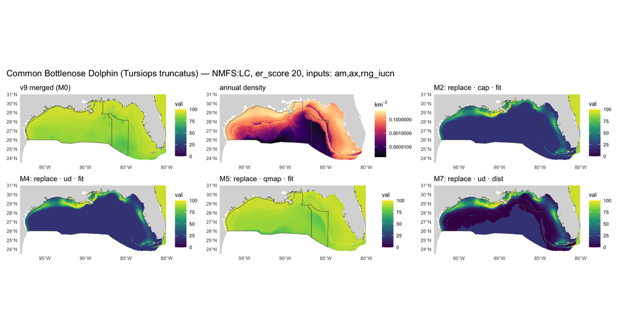

Figure 3: Common bottlenose dolphin: an MMPA-floored species (er 20) with AquaMaps + AquaX + IUCN range. The v9 surface (top left) is AquaX suitability at a mean near 90; the SEFSC density (top middle) resolves the shelf and the Mississippi delta; replacement with cap (M2) or ud (M4) lowers the level to the survey model’s — three quarters of the Gulf sits at the floor of 20 — while qmap (M5) keeps AquaX’s level and redistributes it, and the distribution treatment (M7) removes the floor so the deep-water lows read as lows.

```r
species_fig(key_of("Tursiops truncatus"), "gm")
```

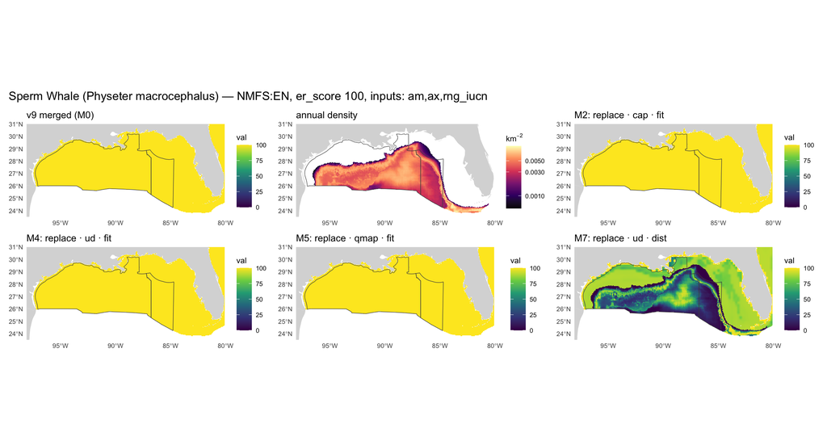

Figure 4: Sperm whale, NMFS Endangered (er 100): under the fitting point (M2, M4, M5) the merged surface stays a flat 100 whatever the density; only the distribution treatment (M7) shows the slope-water concentration the survey model found.

```r
species_fig(key_of("Physeter macrocephalus"), "gm")
```

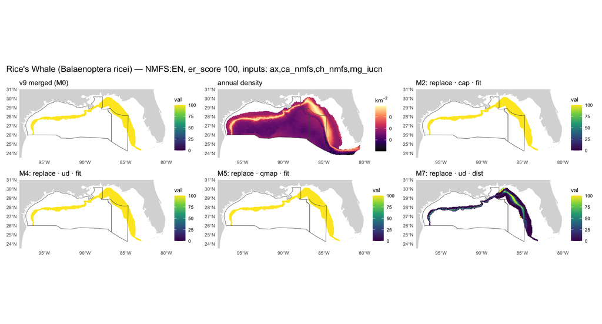

Figure 5: Rice’s whale, NMFS Endangered (er 100), inputs AquaX + NMFS core area + critical habitat + IUCN range: the SEFSC model is the only survey-based surface the atlas holds for it. Same story as the sperm whale: invisible under fit, visible under dist.

```r
species_fig(key_of("Balaenoptera ricei"), "gm")
```

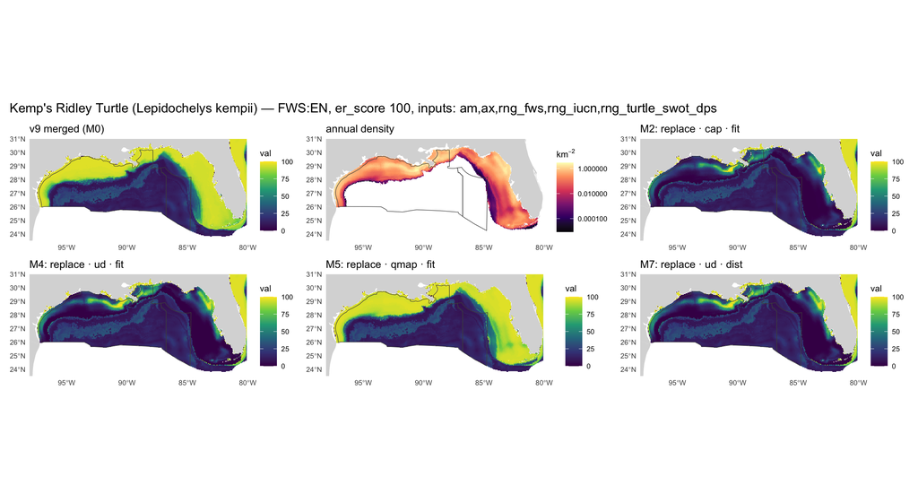

Figure 6: Kemp’s ridley (sea-turtle multiplicative rule, ER × suitability with critical habitat overriding): the density enters as the suitability term, so replacement with cap (M2) or ud (M4) lowers the Gulf from AquaX’s level (mean 87) to the survey model’s (mean 18–20) while keeping the shelf structure; qmap (M5) keeps the level. M7 is M4 for turtles (their rule has no separate dist branch).

```r
species_fig(key_of("Lepidochelys kempii"), "gm")
```

### 8.2 Atlantic and Pacific seabirds (`nc`)

For every bird here the v9 surface is the BirdLife range at the MBTA floor (a flat 10), so `qmap` has no incumbent and M5 equals M2, and `max` (M1) equals M2 (nothing to supersede). The panels show the range-masked methods (M2, M4) beside the union-footprint ones (M8, M9): the difference between M4 and M8 is the part of the survey model the BirdLife range would discard.

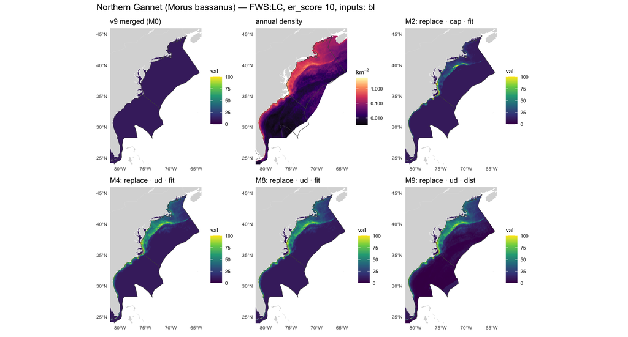

Figure 7: Northern gannet (Atlantic, winter–spring shelf concentration; er 10): from a flat range to a graded surface under every method; cap (M2) leaves four fifths of the carried domain at the floor, ud (M4) three fifths; admitting the domain to the footprint (M8) recovers the offshore part of the NCCOS surface the BirdLife range excludes, and the distribution treatment (M9) lets its lows fall below the floor.

```r
species_fig(key_of("NOGA"), "atl", after = c("M2", "M4", "M8", "M9"))
```

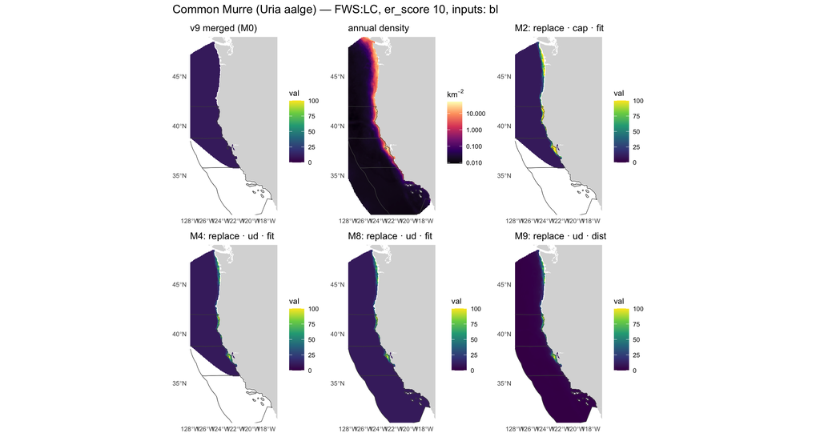

Figure 8: Common murre (Pacific; the most heavy-tailed density in the set, cap 17.9 km⁻²): cap and ud both leave a third of the carried domain at the floor — the colonies hold the population; the union footprint (M8) extends the surface to the whole NCCOS domain and the distribution treatment (M9) draws the offshore gradient.

```r
species_fig(key_of("COMU"), "pac", after = c("M2", "M4", "M8", "M9"))
```

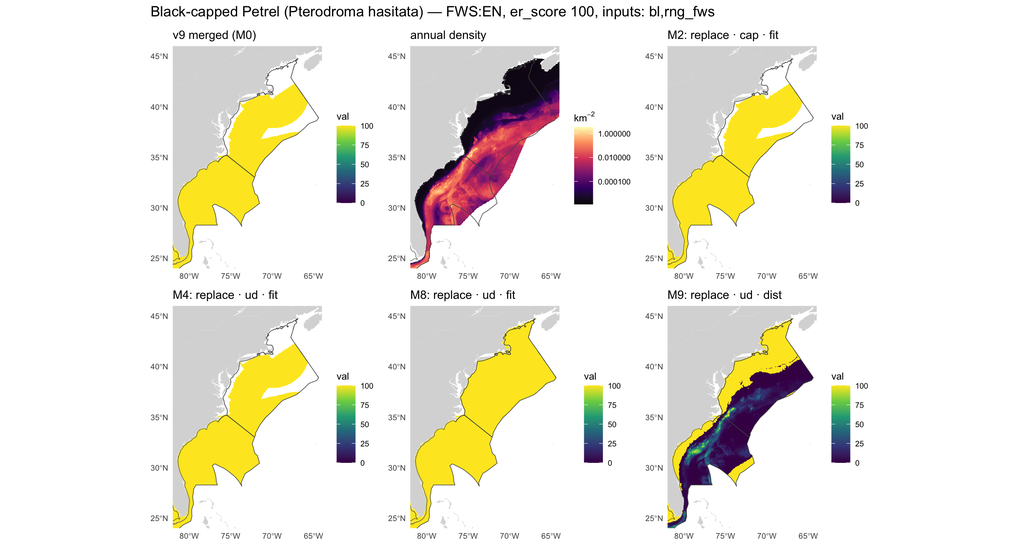

Figure 9: Black-capped petrel (Atlantic, FWS Endangered, er 100): the one Endangered bird with an NCCOS surface; under fit (M2, M4, M8) it stays a flat 100 like the sperm whale; only M9 shows the Gulf Stream concentration the survey model found.

```r
species_fig(key_of("BCPE"), "atl", after = c("M2", "M4", "M8", "M9"))
```

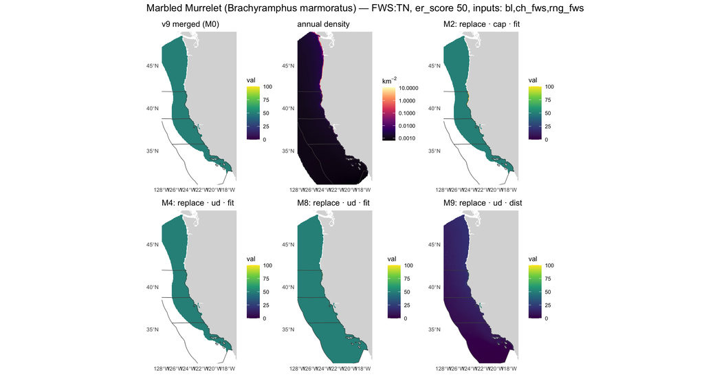

Figure 10: Marbled murrelet (Pacific, FWS Threatened, er 50): the floor binds over half the scale, so under fit (M2, M4) the carried cells sit at 50 and the survey model is invisible; the union footprint (M8) adds the offshore domain — at the floor; only the distribution treatment (M9) shows the nearshore concentration.

```r
species_fig(key_of("MAMU"), "pac", after = c("M2", "M4", "M8", "M9"))
```

### 8.3 The seam at the domain boundary

Replacement changes values only inside the density domain, so whatever the transform does to the *level* of the surface appears as a step at the boundary. The difference maps show it for the bottlenose dolphin: `cap` (M2) lowers most of the Gulf against the AquaX values beyond the domain edge (a step down at the boundary); `qmap` (M5) keeps the incumbent’s marginal so the step is only where the two models disagree about *where* the animals are.

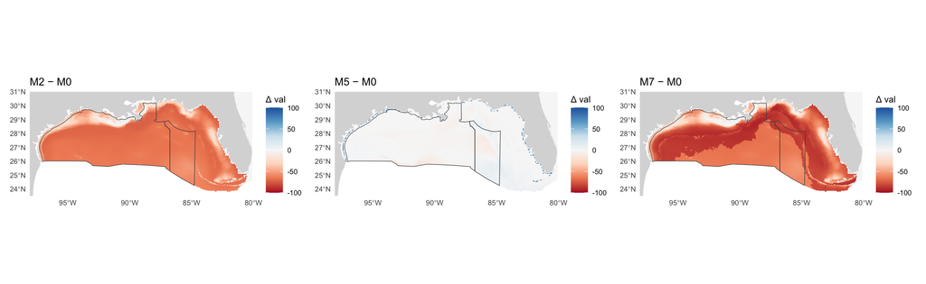

```r
key <- key_of("Tursiops truncatus")
seam_panel <- function(mth) {
  d <- dbGetQuery(con, glue("
    SELECT coalesce(m.cell_id, z.cell_id) AS cell_id, coalesce(m.val, 0) - coalesce(z.val, 0) AS val
    FROM (SELECT cell_id, val FROM merged WHERE method = '{mth}' AND mdl_key = '{key}') m
    FULL JOIN (SELECT cell_id, val FROM merged WHERE method = 'M0' AND mdl_key = '{key}') z USING (cell_id)"))
  b <- boxes$gm
  ggplot() + geom_spatraster(data = cells_to_rast(d, b$xlim, b$ylim)) +
    scale_fill_distiller(palette = "RdBu", limits = c(-100, 100), na.value = NA, direction = 1) +
    geom_sf(data = land, fill = "grey85", colour = NA) +
    geom_sf(data = ply_pa, fill = NA, colour = "grey30", linewidth = 0.25) +
    coord_sf(xlim = b$xlim, ylim = b$ylim, expand = FALSE) +
    labs(title = glue("{mth} − M0"), fill = "Δ val") + theme_minimal(base_size = 9) +
    theme(axis.title = element_blank(), panel.grid = element_blank())
}
wrap_plots(lapply(c("M2", "M5", "M7"), seam_panel), ncol = 3)
```

## 9 What each method does to the scores

The scoring is re-run for each method the way `score_cell_metrics` and `score_zone_metrics` do it — the category sums `extrisk_{cat} = Σ er × val / 100` move only by the affected taxa’s deltas, then every category is min–max rescaled per ecoregion, the equal-weight composite is the mean of the present components, and zones take the coverage-weighted mean with the `pct_area` down-weight. The baseline is recomputed from `cell_metric` by the same code and asserted equal to the published `zone_metric`, so the method columns are comparable to it.

```r
# taxon weights as score_cell_metrics applies them (no 'cell'-mode taxa here, asserted above)
dbExecute(con, "CREATE OR REPLACE TABLE w AS
  SELECT t.ms_merge_key, t.sp_cat, CASE WHEN t.er_mode = 'premultiplied' THEN 100.0 ELSE t.er_score END AS w
  FROM sdm.taxon t WHERE t.ms_merge_key IN (SELECT DISTINCT mdl_key FROM merged)")
```

```
[1] 81
```

```r
# Δ extrisk per (method, category, cell) = Σ_taxa w × (val_method − val_M0) / 100
dbExecute(con, "CREATE OR REPLACE TABLE delta AS
  WITH m AS (SELECT method, mdl_key, cell_id, val FROM merged WHERE method <> 'M0'),
       z AS (SELECT mdl_key, cell_id, val FROM merged WHERE method = 'M0'),
       u AS (SELECT method, mdl_key, cell_id FROM m
             UNION SELECT mm.method, z.mdl_key, z.cell_id FROM z CROSS JOIN (SELECT DISTINCT method FROM m) mm)
  SELECT u.method, w.sp_cat, u.cell_id, sum(w.w * (coalesce(m.val, 0) - coalesce(z.val, 0))) / 100.0 AS d
  FROM u LEFT JOIN m USING (method, mdl_key, cell_id) LEFT JOIN z USING (mdl_key, cell_id)
  JOIN w ON w.ms_merge_key = u.mdl_key GROUP BY 1, 2, 3")
```

```
[1] 13277700
```

```r
# base metrics of the release, keyed by category; the baseline is method 'M0' with no delta
base_keys <- paste(sprintf("'extrisk_%s'", sp_cats), collapse = ",")
dbExecute(con, glue("CREATE OR REPLACE TABLE base AS
  SELECT cm.cell_id, replace(m.metric_key, 'extrisk_', '') AS sp_cat, cm.val
  FROM sdm.cell_metric cm JOIN sdm.metric m USING (metric_seq) WHERE m.metric_key IN ({base_keys})"))
```

```
[1] 3937191
```

```r
dbExecute(con, "CREATE OR REPLACE TABLE base_new AS
  WITH mm AS (SELECT DISTINCT method FROM merged),
       k  AS (SELECT mm.method, b.cell_id, b.sp_cat FROM base b CROSS JOIN mm
              UNION SELECT method, cell_id, sp_cat FROM delta)
  SELECT k.method, k.cell_id, k.sp_cat, coalesce(b.val, 0) + coalesce(d.d, 0) AS val
  FROM k LEFT JOIN base b USING (cell_id, sp_cat) LEFT JOIN delta d USING (method, cell_id, sp_cat)")
```

```
[1] 39371910
```

```r
# ecoregion min/max → per-cell rescale (coverage-normalized across ecoregions), as score_cell_metrics
dbExecute(con, "CREATE OR REPLACE TABLE eco AS
  SELECT zc.cell_id, zc.zone_seq, zc.pct_covered * 100.0 / sum(zc.pct_covered) OVER (PARTITION BY zc.cell_id) AS norm_pct
  FROM sdm.zone_cell zc JOIN sdm.zone z USING (zone_seq) WHERE z.fld = 'ecoregion_key'")
```

```
[1] 630944
```

```r
dbExecute(con, "CREATE OR REPLACE TABLE rescaled AS
  WITH mm AS (SELECT bn.method, bn.sp_cat, e.zone_seq, min(bn.val) AS min_v, max(bn.val) AS max_v
              FROM base_new bn JOIN eco e USING (cell_id) GROUP BY 1, 2, 3)
  SELECT bn.method, bn.sp_cat AS component, bn.cell_id,
         sum((bn.val - mm.min_v) / (mm.max_v - mm.min_v) * (e.norm_pct / 100.0)) * 100 AS val
  FROM base_new bn JOIN eco e USING (cell_id)
  JOIN mm ON mm.method = bn.method AND mm.sp_cat = bn.sp_cat AND mm.zone_seq = e.zone_seq
  WHERE mm.min_v < mm.max_v GROUP BY 1, 2, 3
  UNION ALL
  SELECT mm.method, 'primprod', cm.cell_id, cm.val
  FROM sdm.cell_metric cm JOIN sdm.metric m USING (metric_seq) CROSS JOIN (SELECT DISTINCT method FROM merged) mm
  WHERE m.metric_key = 'primprod_ecoregion_rescaled'")
```

```
[1] 44804420
```

```r
dbExecute(con, "CREATE OR REPLACE TABLE composite AS
  SELECT method, cell_id, round(avg(val)) AS val FROM rescaled GROUP BY 1, 2")
```

```
[1] 6232120
```

```r
# zones: component → zone (coverage-weighted mean × pct_area), composite = mean of present components
dbExecute(con, "CREATE OR REPLACE TABLE zone_comp AS
  WITH zc AS (SELECT zc.zone_seq, zc.cell_id, zc.pct_covered, z.fld, z.val AS zone FROM sdm.zone_cell zc JOIN sdm.zone z USING (zone_seq)),
       cov AS (SELECT zone_seq, sum(pct_covered) AS cov_all FROM zc GROUP BY 1)
  SELECT r.method, zc.fld, zc.zone, r.component,
         sum(r.val * zc.pct_covered) / sum(zc.pct_covered) * (sum(zc.pct_covered) / any_value(cov.cov_all)) AS val
  FROM zc JOIN rescaled r USING (cell_id) JOIN cov USING (zone_seq)
  GROUP BY 1, 2, 3, 4")
```

```
[1] 2850
```

```r
zone_scores <- dbGetQuery(con, "
  SELECT method, fld, zone, avg(val) AS score FROM zone_comp GROUP BY 1, 2, 3 ORDER BY 2, 3, 1")

# the baseline must equal the published zone_metric composite (the same SQL, so the method columns
# are comparable to what the apps show)
pub <- dbGetQuery(con, "SELECT z.fld, z.val AS zone, zm.val AS score_pub FROM sdm.zone z JOIN sdm.zone_metric zm USING (zone_seq)
  JOIN sdm.metric m USING (metric_seq) WHERE m.metric_key = 'score_extriskspcat_primprod_ecoregionrescaled_equalweights'")
chk_z <- zone_scores |> filter(method == "M0") |> inner_join(pub, by = c("fld", "zone")) |> mutate(d = abs(score - score_pub))
stopifnot("the recomputed M0 zone composite must equal the published zone_metric" = nrow(chk_z) == nrow(pub), max(chk_z$d) < 1e-3)
```

```r
# the involved areas: zones whose cells intersect a density domain
involved <- dbGetQuery(con, "
  SELECT DISTINCT z.fld, z.val AS zone FROM sdm.zone z JOIN sdm.zone_cell zc USING (zone_seq)
  JOIN (SELECT DISTINCT cell_id FROM dens) d USING (cell_id)")
zone_names <- bind_rows(
  ply_pa |> st_drop_geometry() |> transmute(fld = "programarea_key", zone = programarea_key, name = programarea_name),
  ply_er |> st_drop_geometry() |> transmute(fld = "ecoregion_key", zone = ecoregion_key, name = ecoregion_name),
  tibble(fld = "subregion_key", zone = c("AK", "AT", "GA", "PA", "USA"),
         name = c("Alaska", "Atlantic", "Gulf of America", "Pacific", "United States")))
zt <- zone_scores |> inner_join(involved, by = c("fld", "zone")) |>
  pivot_wider(names_from = method, values_from = score) |>
  mutate(across(starts_with("M"), ~ round(.x, 1))) |>
  left_join(zone_names, by = c("fld", "zone")) |>
  mutate(fld = str_remove(fld, "_key")) |> relocate(name, .after = zone) |> arrange(fld, zone)
kable(zt, caption = "Composite score of every zone that intersects a density domain: v9 (M0) and each method. Program Areas: GAA/GAB (Gulf), CEC/NOC/SOC (Pacific); the Atlantic has no 2026 Program Area, so its ecoregions (NECS, SECS) and subregion carry the Atlantic seabird effect.")
```

Table 3: Composite score of every zone that intersects a density domain: v9 (M0) and each method. Program Areas: GAA/GAB (Gulf), CEC/NOC/SOC (Pacific); the Atlantic has no 2026 Program Area, so its ecoregions (NECS, SECS) and subregion carry the Atlantic seabird effect.

| fld | zone | name | M0 | M1 | M2 | M3 | M4 | M5 | M6 | M7 | M8 | M9 |
| --- | --- | --- | --- | --- | --- | --- | --- | --- | --- | --- | --- | --- |
| ecoregion | CAC | California Current | 22.7 | 22.6 | 22.6 | 23.2 | 23.0 | 22.6 | 22.1 | 22.9 | 22.9 | 23.2 |
| ecoregion | EGOA | Eastern Gulf of America | 34.1 | 33.3 | 33.0 | 32.7 | 33.3 | 33.4 | 34.0 | 33.8 | 33.6 | 33.7 |
| ecoregion | NECS | Northeast Continental Shelf | 32.7 | 32.9 | 32.9 | 33.5 | 33.0 | 32.9 | 31.5 | 32.1 | 37.5 | 31.4 |
| ecoregion | SECS | Southeast Continental Shelf | 36.0 | 35.8 | 36.3 | 35.9 | 36.1 | 35.9 | 35.4 | 35.0 | 39.3 | 34.7 |
| ecoregion | WAOR | Washington/Oregon | 23.6 | 22.6 | 22.6 | 22.9 | 23.7 | 22.6 | 20.9 | 22.8 | 22.5 | 22.6 |
| ecoregion | WCGOA | Western and Central Gulf of America | 43.6 | 43.4 | 40.7 | 41.6 | 41.0 | 43.2 | 40.0 | 40.5 | 43.5 | 41.1 |
| programarea | CEC | Central California | 21.9 | 21.7 | 21.7 | 22.4 | 22.2 | 21.7 | 20.9 | 21.8 | 21.7 | 22.1 |
| programarea | GAA | GOA Program Area A | 40.4 | 40.2 | 38.0 | 38.4 | 38.2 | 39.9 | 37.5 | 38.0 | 40.6 | 38.5 |
| programarea | GAB | GOA Program Area B | 18.1 | 16.9 | 19.0 | 15.9 | 19.0 | 16.3 | 19.7 | 19.0 | 19.9 | 19.3 |
| programarea | NOC | Northern California | 16.8 | 17.1 | 17.1 | 18.1 | 17.7 | 17.1 | 16.7 | 17.6 | 17.6 | 18.1 |
| programarea | SOC | Southern California | 27.2 | 26.8 | 26.8 | 27.1 | 27.2 | 26.8 | 26.5 | 27.0 | 27.2 | 27.2 |
| subregion | AT | Atlantic | 34.4 | 34.4 | 34.6 | 34.7 | 34.6 | 34.4 | 33.5 | 33.7 | 37.9 | 33.2 |
| subregion | GA | Gulf of America | 39.1 | 38.6 | 37.1 | 37.4 | 37.3 | 38.5 | 37.2 | 37.3 | 38.8 | 37.6 |
| subregion | PA | Pacific | 18.6 | 18.5 | 18.5 | 18.6 | 18.6 | 18.5 | 19.1 | 19.3 | 18.6 | 19.3 |
| subregion | USA | United States | 21.2 | 21.2 | 21.2 | 21.2 | 21.2 | 21.2 | 21.3 | 21.3 | 21.5 | 21.3 |

```r
# the version-equivalence gate numbers, per method, over the 20 Program Areas (msens::score_delta)
pa0 <- zone_scores |> filter(method == "M0", fld == "programarea_key") |> transmute(programarea_key = zone, score)
gate <- bind_rows(lapply(setdiff(methods$method, "M0"), function(m) {
  pa <- zone_scores |> filter(method == m, fld == "programarea_key") |> transmute(programarea_key = zone, score)
  d  <- msens::score_delta(pa0, pa, labels = c("v9", m))
  s  <- msens::score_delta_summary(d)
  tibble(method = m, n_pa = s$n, mean_abs = round(s$mean_abs, 2), max_abs = round(s$max_abs, 2),
         max_at = d$programarea_key[1], rmse = round(s$rmse, 2))
})) |> left_join(methods |> select(method, transform, mosaic, er), by = "method")
kable(gate)
```

Table 4: Program-Area composite, each method against v9: mean and maximum absolute change over the 20 areas (the same statistics the release gate msens::pra_score_delta reports; v8→v9 AquaX moved them by mean 4.0 / max 9.0)

| method | n_pa | mean_abs | max_abs | max_at | rmse | transform | mosaic | er |
| --- | --- | --- | --- | --- | --- | --- | --- | --- |
| M1 | 20 | 0.11 | 1.18 | GAB | 0.29 | cap | max | fit |
| M2 | 20 | 0.21 | 2.45 | GAA | 0.60 | cap | replace | fit |
| M3 | 20 | 0.31 | 2.18 | GAB | 0.74 | log | replace | fit |
| M4 | 20 | 0.22 | 2.22 | GAA | 0.58 | ud | replace | fit |
| M5 | 20 | 0.16 | 1.72 | GAB | 0.42 | qmap | replace | fit |
| M6 | 20 | 0.52 | 2.90 | GAA | 0.88 | cap | replace | dist |
| M7 | 20 | 0.44 | 2.49 | GAA | 0.73 | ud | replace | dist |
| M8 | 20 | 0.15 | 1.83 | GAB | 0.45 | ud | replace | fit |
| M9 | 20 | 0.45 | 1.95 | GAA | 0.71 | ud | replace | dist |

```r
comp <- dbGetQuery(con, "SELECT method, fld, zone, component, val FROM zone_comp WHERE component IN ('mammal','turtle','bird')") |>
  inner_join(involved, by = c("fld", "zone")) |>
  mutate(val = round(val, 1)) |>
  pivot_wider(names_from = method, values_from = val) |>
  mutate(fld = str_remove(fld, "_key")) |> arrange(component, fld, zone)
kable(comp, caption = "The three affected components (ecoregion-rescaled, coverage-weighted, pct_area-weighted) per involved zone and method")
g_m <- function(m, col) gate[[col]][gate$method == m]
cv <- function(component_, zone_, m) {
  x <- dbGetQuery(con, glue("SELECT val FROM zone_comp WHERE component = '{component_}' AND zone = '{zone_}' AND method = '{m}'"))$val
  round(x, 1)
}
```

Table 5: The three affected components (ecoregion-rescaled, coverage-weighted, pct_area-weighted) per involved zone and method

| fld | zone | component | M4 | M3 | M7 | M1 | M5 | M8 | M2 | M9 | M6 | M0 |
| --- | --- | --- | --- | --- | --- | --- | --- | --- | --- | --- | --- | --- |
| ecoregion | CAC | bird | 18.1 | 19.0 | 17.1 | 14.4 | 14.4 | 16.9 | 14.4 | 19.5 | 11.4 | 15.6 |
| ecoregion | EGOA | bird | 28.0 | 28.0 | 31.9 | 28.0 | 28.0 | 20.1 | 28.0 | 28.0 | 37.2 | 28.0 |
| ecoregion | NECS | bird | 47.4 | 51.1 | 40.9 | 46.2 | 46.2 | 83.2 | 46.2 | 35.2 | 36.1 | 45.1 |
| ecoregion | SECS | bird | 51.0 | 51.4 | 38.6 | 52.2 | 52.2 | 78.6 | 52.2 | 38.1 | 42.4 | 54.4 |
| ecoregion | WAOR | bird | 37.1 | 31.0 | 30.5 | 28.7 | 28.7 | 27.8 | 28.7 | 28.9 | 15.1 | 36.3 |
| ecoregion | WCGOA | bird | 55.9 | 55.9 | 55.9 | 55.9 | 55.9 | 55.9 | 55.9 | 55.9 | 56.0 | 55.9 |
| programarea | CEC | bird | 20.8 | 22.3 | 18.2 | 16.6 | 16.6 | 17.0 | 16.6 | 20.4 | 11.2 | 18.5 |
| programarea | GAA | bird | 52.8 | 52.8 | 53.2 | 52.8 | 52.8 | 51.9 | 52.8 | 52.8 | 53.8 | 52.8 |
| programarea | GAB | bird | 31.1 | 31.1 | 34.8 | 31.1 | 31.1 | 22.3 | 31.1 | 31.1 | 40.0 | 31.1 |
| programarea | NOC | bird | 17.8 | 20.9 | 17.6 | 12.9 | 12.9 | 17.2 | 12.9 | 21.4 | 10.3 | 10.9 |
| programarea | SOC | bird | 16.9 | 15.9 | 16.2 | 14.2 | 14.2 | 16.7 | 14.2 | 17.7 | 12.3 | 17.2 |
| subregion | AT | bird | 47.4 | 49.3 | 39.6 | 47.3 | 47.3 | 74.9 | 47.3 | 36.7 | 38.7 | 47.6 |
| subregion | GA | bird | 42.7 | 42.7 | 44.5 | 42.7 | 42.7 | 39.0 | 42.7 | 42.7 | 47.1 | 42.7 |
| subregion | PA | bird | 38.6 | 38.4 | 38.2 | 37.8 | 37.8 | 38.0 | 37.8 | 38.3 | 36.9 | 38.3 |
| subregion | USA | bird | 36.0 | 36.0 | 35.2 | 35.7 | 35.7 | 37.9 | 35.7 | 35.0 | 34.8 | 35.9 |
| ecoregion | CAC | mammal | 40.7 | 40.7 | 40.1 | 40.7 | 40.7 | 40.7 | 40.7 | 40.1 | 40.1 | 40.7 |
| ecoregion | EGOA | mammal | 42.2 | 42.9 | 42.1 | 44.9 | 44.5 | 52.3 | 42.4 | 45.2 | 41.2 | 45.9 |
| ecoregion | NECS | mammal | 66.8 | 66.8 | 65.8 | 66.8 | 66.8 | 66.8 | 66.8 | 65.8 | 65.8 | 66.8 |
| ecoregion | SECS | mammal | 67.9 | 65.9 | 71.2 | 65.3 | 65.3 | 65.6 | 68.4 | 69.2 | 70.6 | 65.3 |
| ecoregion | WAOR | mammal | 26.9 | 26.9 | 26.7 | 26.9 | 26.9 | 26.9 | 26.9 | 26.7 | 26.7 | 26.9 |
| ecoregion | WCGOA | mammal | 45.9 | 45.9 | 42.3 | 59.4 | 55.9 | 65.9 | 44.8 | 46.9 | 39.2 | 59.5 |
| programarea | CEC | mammal | 40.9 | 40.9 | 40.4 | 40.9 | 40.9 | 40.9 | 40.9 | 40.4 | 40.4 | 40.9 |
| programarea | GAA | mammal | 43.2 | 43.0 | 40.5 | 56.2 | 52.9 | 63.3 | 42.1 | 45.3 | 37.5 | 56.4 |
| programarea | GAB | mammal | 21.1 | 21.4 | 16.8 | 27.2 | 27.7 | 36.8 | 20.7 | 23.3 | 16.8 | 28.6 |
| programarea | NOC | mammal | 24.0 | 24.0 | 23.7 | 24.0 | 24.0 | 24.0 | 24.0 | 23.7 | 23.7 | 24.0 |
| programarea | SOC | mammal | 51.9 | 51.9 | 51.2 | 51.9 | 51.9 | 51.9 | 51.9 | 51.2 | 51.2 | 51.9 |
| subregion | AT | mammal | 68.0 | 67.3 | 68.6 | 67.1 | 67.1 | 67.2 | 68.2 | 67.9 | 68.4 | 67.1 |
| subregion | GA | mammal | 44.2 | 44.5 | 42.2 | 52.5 | 50.5 | 59.5 | 43.7 | 46.1 | 40.1 | 53.1 |
| subregion | PA | mammal | 32.5 | 32.5 | 38.0 | 32.5 | 32.5 | 32.5 | 32.5 | 38.0 | 38.0 | 32.5 |
| subregion | USA | mammal | 33.6 | 33.5 | 35.5 | 33.8 | 33.8 | 34.1 | 33.6 | 35.5 | 35.4 | 33.8 |
| ecoregion | CAC | turtle | 58.3 | 58.3 | 58.3 | 58.3 | 58.3 | 58.3 | 58.3 | 58.3 | 58.3 | 58.3 |
| ecoregion | EGOA | turtle | 52.6 | 46.9 | 52.6 | 50.1 | 51.0 | 52.6 | 50.1 | 52.6 | 50.1 | 55.2 |
| ecoregion | NECS | turtle | 66.8 | 66.8 | 66.8 | 66.8 | 66.8 | 66.8 | 66.8 | 66.8 | 66.8 | 66.8 |
| ecoregion | SECS | turtle | 66.6 | 66.9 | 66.6 | 65.2 | 66.1 | 66.6 | 66.6 | 66.6 | 66.6 | 65.2 |
| ecoregion | WAOR | turtle | 37.2 | 37.2 | 37.2 | 37.2 | 37.2 | 37.2 | 37.2 | 37.2 | 37.2 | 37.2 |
| ecoregion | WCGOA | turtle | 75.8 | 80.4 | 75.8 | 82.1 | 83.2 | 75.8 | 74.8 | 75.8 | 74.8 | 82.9 |
| programarea | CEC | turtle | 61.5 | 61.5 | 61.5 | 61.5 | 61.5 | 61.5 | 61.5 | 61.5 | 61.5 | 61.5 |
| programarea | GAA | turtle | 74.0 | 75.2 | 74.0 | 76.9 | 77.4 | 74.0 | 73.2 | 74.0 | 73.2 | 78.5 |
| programarea | GAB | turtle | 60.9 | 35.3 | 60.9 | 37.6 | 32.7 | 60.9 | 61.4 | 60.9 | 61.4 | 45.6 |
| programarea | NOC | turtle | 55.7 | 55.7 | 55.7 | 55.7 | 55.7 | 55.7 | 55.7 | 55.7 | 55.7 | 55.7 |
| programarea | SOC | turtle | 58.3 | 58.3 | 58.3 | 58.3 | 58.3 | 58.3 | 58.3 | 58.3 | 58.3 | 58.3 |
| subregion | AT | turtle | 66.8 | 66.9 | 66.8 | 66.2 | 66.6 | 66.8 | 66.8 | 66.8 | 66.8 | 66.2 |
| subregion | GA | turtle | 64.8 | 64.6 | 64.8 | 66.9 | 67.9 | 64.8 | 63.1 | 64.8 | 63.1 | 69.8 |
| subregion | PA | turtle | 37.0 | 37.0 | 37.0 | 37.0 | 37.0 | 37.0 | 37.0 | 37.0 | 37.0 | 37.0 |
| subregion | USA | turtle | 31.2 | 31.2 | 31.2 | 31.3 | 31.3 | 31.2 | 31.2 | 31.2 | 31.2 | 31.4 |

- **Replacement lowers the Gulf mammal component** from 56.4 (v9) to 42.1–43.2 in GAA under cap, log or ud, because AquaX paints the Gulf dolphins at a mean near 90 and the survey models’ relative densities average 25–35. `max` (M1: 56.2) leaves it untouched, and qmap (M5: 52.9) keeps the level by construction. Which of these is *right* is the seam question of § Section 8.3: the survey model says most of the Gulf holds few dolphins per km² relative to the delta and shelf edge; AquaX says most of the Gulf is environmentally fine.
- **The distribution treatment moves the most** (M6 mean 0.52, M7 0.44 over the 20 areas) because it also removes the floor of the Endangered species — the sperm whale and Rice’s whale stop contributing a flat 100 across the Gulf — and lifts the Atlantic mammal component (SECS 65.3 → 71.2) by the same rescaling.
- **The ecoregional min–max rescale amplifies small input changes.** The turtle component of GAB ranges from 32.7 to 61.4 across transforms (v9 45.6) although the four turtle surfaces themselves change similarly under all of them: the transform decides which cell holds the ecoregion’s maximum, and every other cell is rescaled against it. This is the fragility the v7.1 patch met and the v10 distribution-share method removes; it is not a property of the density data.
- **The expert-range mask discards most of a seabird’s survey model.** The merge masks every suitability input to the taxon’s range, and for a typical `nc` bird only 30 % of the NCCOS domain lies inside its BirdLife marine range (Table 1); the `gm` taxa’s IUCN ranges cover their whole Gulf domain. Admitting the domain to the footprint (M8 vs M4) is what turns the seabird fold-in from a nearshore retouch into a shelf-wide surface: the Northeast-shelf bird component goes 47.4 → 83.2, the Pacific 38.6 → 38.

The seabird components otherwise move less than the mammals’ because the v9 bird surfaces are flat MBTA floors and the density adds structure without a level to lose.

## 10 Temporal resolution: what the annual mean hides

Both sources are monthly or seasonal; the scoring surface is annual. The ratio of the peak interval’s domain-mean density to the annual mean says how much a static surface understates the season that matters for a take estimate — NMFS authorizations use the *highest seasonal mean* density, not the annual (National Marine Fisheries Service 2023b), and the choice of temporal resolution should follow the ecology (Mannocci et al. 2017).

```r
gm_t <- gm_cells |> group_by(taxa_sci, mm) |> summarise(dens = mean(dens), .groups = "drop") |>
  group_by(taxa_sci) |> summarise(n_intervals = n(), peak = max(dens), peak_interval = mm[which.max(dens)],
                                  annual = sum(dens) / 12, .groups = "drop") |>
  transmute(ds_key = "gm", taxon = taxa_sci, n_intervals, peak_interval, peak_over_annual = round(peak / annual, 1))
nc_t <- nc_cells |> group_by(sp_code, region, season) |> summarise(dens = mean(dens), .groups = "drop") |>
  group_by(sp_code, region) |> summarise(n_intervals = n(), peak = max(dens), peak_interval = season[which.max(dens)],
                                         annual = sum(dens) / 4, .groups = "drop") |>
  transmute(ds_key = "nc", taxon = glue("{sp_code} ({region})"), n_intervals, peak_interval, peak_over_annual = round(peak / annual, 1))
tt <- bind_rows(gm_t, nc_t)
kable(tt |> group_by(ds_key) |> summarise(models = n(), ratio_median = median(peak_over_annual), ratio_max = max(peak_over_annual),
        modelled_all_intervals = sum(n_intervals == if_else(ds_key[1] == "gm", 12, 4))),
      caption = "Peak-interval domain-mean density over the annual mean: a ratio of 4 (a species present one season of four) is the factor by which the annual surface understates the season a take estimate would use")
kable(tt |> arrange(desc(peak_over_annual)) |> head(15), caption = "The 15 most seasonal models")
```

| ds_key | models | ratio_median | ratio_max | modelled_all_intervals |
| --- | --- | --- | --- | --- |
| gm | 17 | 1.6 | 2.4 | 16 |
| nc | 93 | 2.4 | 4.0 | 33 |

| ds_key | taxon | n_intervals | peak_interval | peak_over_annual |
| --- | --- | --- | --- | --- |
| nc | ANMU (Pacific) | 1 | spring | 4.0 |
| nc | ARTE (Atlantic) | 1 | summer | 4.0 |
| nc | BLGU (Atlantic) | 1 | summer | 4.0 |
| nc | BRSP (Atlantic) | 1 | summer | 4.0 |
| nc | GRSK (Atlantic) | 1 | fall | 4.0 |
| nc | HOGR (Atlantic) | 1 | winter | 4.0 |
| nc | MUPE (Pacific) | 1 | spring | 4.0 |
| nc | SCMU-GUMU-CRMU (Pacific) | 1 | spring | 4.0 |
| nc | SPSK (Pacific) | 1 | fall | 4.0 |
| nc | BLKI (Pacific) | 3 | winter | 3.9 |
| nc | BLKI (Atlantic) | 3 | winter | 3.8 |
| nc | COLO (Pacific) | 2 | spring | 3.8 |
| nc | RTLO (Pacific) | 2 | spring | 3.8 |
| nc | LAAL (Pacific) | 2 | winter | 3.7 |
| nc | WISP (Atlantic) | 3 | summer | 3.6 |

## 11 Audit of the v8/v9 ingests

Re-deriving the density exposed two faults in the ingested `dist/dataset={gm,nc}` surfaces that hold whatever method is adopted:

1. **`gm`: raw density rounded to two decimals before rescaling.** `cells_from_raster()` rounds `val` to the atlas’ [0,100] precision; the gm ingest passed it *density* (0.001–0.01 km<sup>-2</sup> for the beaked whales, sperm whale, Rice’s whale, *Kogia*), so every cell below 0.005 became 0 and the survivors were quantized to 0.01 — then divided by a p99.5 cap smaller than that. The published beaked-whale and Rice’s-whale surfaces are a flat 100 over a fraction of their domain and the sperm whale sits at 90. Fixed by `cells_from_raster(digits = )` (msens 0.45.0, regression test in `test-ingest.R`); the ingest should rescale before calling it, as the nc ingest does.
2. **Both: the annual mean averaged only the intervals a cell was present in**, which biases every annual cell upward, most for the sparsest species. `msens::density_annual()` counts an absent interval as zero.

```r
# the ingested annual surface vs this page's cap transform of the re-derived annual density, per taxon
ing <- dbGetQuery(con, glue("
  SELECT split_part(mdl_key, '|', 1) AS ds_key, split_part(mdl_key, '|', 2) AS sp_id, cell_id, val
  FROM read_parquet(['{dir_dist}/dataset=gm/*.parquet', '{dir_dist}/dataset=nc/*.parquet'])
  WHERE mdl_key NOT LIKE '%|%|%'"))
duckdb_register(con, "ing_r", ing)
duckdb_register(con, "tx_r", tx |> select(ms_merge_key, ds_key, sp_id = ingest_sp_id))
audit <- dbGetQuery(con, "
  WITH t AS (SELECT ms_merge_key, ds_key, sp_id FROM tx_r),
       re AS (SELECT s.ms_merge_key, s.cell_id, s.val FROM dens_suit s WHERE s.transform = 'cap'),
       n_re AS (SELECT ms_merge_key, count(*) AS n_rederived FROM re GROUP BY 1),
       j  AS (SELECT t.ds_key, t.sp_id, t.ms_merge_key, i.cell_id, i.val AS val_ing, re.val AS val_re
              FROM t LEFT JOIN (SELECT i.* FROM ing_r i JOIN us_cells u USING (cell_id)) i
                ON i.ds_key = t.ds_key AND i.sp_id = t.sp_id
              LEFT JOIN re ON re.ms_merge_key = t.ms_merge_key AND re.cell_id = i.cell_id),
       r  AS (SELECT *, rank() OVER (PARTITION BY sp_id ORDER BY val_ing) AS rk_ing,
                        rank() OVER (PARTITION BY sp_id ORDER BY val_re) AS rk_re FROM j WHERE val_re IS NOT NULL)
  SELECT j.ds_key, j.sp_id, count(DISTINCT j.cell_id) AS n_ingested, any_value(n_re.n_rederived) AS n_rederived,
         round(100.0 * count(*) FILTER (WHERE j.val_ing >= 100) / nullif(count(j.val_ing), 0), 1) AS pct_ingested_at_100,
         (SELECT round(corr(rk_ing, rk_re), 2) FROM r WHERE r.sp_id = j.sp_id) AS rho_shared
  FROM j LEFT JOIN n_re USING (ms_merge_key)
  GROUP BY 1, 2 ORDER BY 1, pct_ingested_at_100 DESC")
duckdb_unregister(con, "ing_r"); duckdb_unregister(con, "tx_r")
kable(audit |> left_join(tx |> select(sp_id = ingest_sp_id, sp_label, common_name), by = "sp_id") |>
        relocate(sp_label, common_name, .after = sp_id) |> select(-sp_id),
      caption = "Ingested annual surface vs the re-derived one, US cells: cells, the share of ingested cells at exactly 100, and the rank agreement on shared cells. A gm row at 100 % is the rounding fault (the sperm whale's constant 90 gives no rank); a large gap between n_ingested and n_rederived is the ≥ 1 threshold on a heavy-tailed cap transform dropping most of the domain (n_rederived keeps every cell with val > 0)")
```

Table 7: Ingested annual surface vs the re-derived one, US cells: cells, the share of ingested cells at exactly 100, and the rank agreement on shared cells. A gm row at 100 % is the rounding fault (the sperm whale’s constant 90 gives no rank); a large gap between n_ingested and n_rederived is the ≥ 1 threshold on a heavy-tailed cap transform dropping most of the domain (n_rederived keeps every cell with val > 0)

| ds_key | sp_label | common_name | n_ingested | n_rederived | pct_ingested_at_100 | rho_shared |
| --- | --- | --- | --- | --- | --- | --- |
| gm | Balaenoptera ricei | Rice’s Whale | 543 | 9278 | 100.0 |  |
| gm | Stenella frontalis | Atlantic Spotted Dolphin | 10834 | 17173 | 0.7 | 0.99 |
| gm | Grampus griseus | Risso’s Dolphin | 4408 | 13767 | 0.0 | 0.38 |
| gm | Dermochelys coriacea | Leatherback Turtle | 8859 | 11799 | 0.0 | 0.87 |
| gm | Stenella coeruleoalba | Striped Dolphin | 13766 | 13767 | 0.0 | 0.98 |
| gm | Caretta caretta | Loggerhead Turtle | 11784 | 11799 | 0.0 | 1.00 |
| gm | Physeter macrocephalus | Sperm Whale | 10110 | 13767 | 0.0 |  |
| gm | Lepidochelys kempii | Kemp’s Ridley Turtle | 9339 | 11557 | 0.0 | 1.00 |
| gm | Stenella attenuata | Pantropical Spotted Dolphin | 13767 | 13767 | 0.0 | 1.00 |
| gm | Stenella longirostris | Spinner Dolphin | 2931 | 11828 | 0.0 | 0.91 |
| gm | Chelonia mydas | Green Turtle | 8795 | 11799 | 0.0 | 0.95 |
| gm | Tursiops truncatus | Common Bottlenose Dolphin | 14558 | 19249 | 0.0 | 1.00 |
| gm | Stenella clymene | Clymene Dolphin | 10897 | 13767 | 0.0 | 0.90 |
| nc | ARTE | Arctic Tern | 6669 | 54798 | 0.7 | 1.00 |
| nc | MUPE | Murphy’s Petrel | 32503 | 51031 | 0.4 | 1.00 |
| nc | BRSP | Band-rumped Storm-petrel | 27408 | 54798 | 0.4 | 0.99 |
| nc | RAZO | Razorbill | 43950 | 54798 | 0.3 | 0.94 |
| nc | GRSK | Great Skua | 43755 | 54798 | 0.3 | 0.99 |
| nc | BLKI | Black-legged Kittiwake | 76063 | 105829 | 0.3 | 0.98 |
| nc | BRAC | Brandt’s Cormorant | 6971 | 51031 | 0.2 | 0.97 |
| nc | TUPU | Tufted Puffin | 28583 | 51031 | 0.1 | 0.97 |
| nc | BCPE | Black-capped Petrel | 19415 | 34286 | 0.1 | 0.93 |
| nc | HOGR | Horned Grebe | 44023 | 54798 | 0.1 | 0.98 |
| nc | WISP | Wilson’s Storm-Petrel | 40287 | 54798 | 0.1 | 0.98 |
| nc | ANMU | Ancient Murrelet | 19075 | 51031 | 0.1 | 1.00 |
| nc | BRPE | Brown Pelican | 31609 | 105829 | 0.1 | 0.72 |
| nc | LTDU | Long-tailed Duck | 43914 | 54798 | 0.1 | 0.79 |
| nc | SPSK | South Polar Skua | 78913 | 105829 | 0.1 | 0.94 |
| nc | DCCO | Double-crested Cormorant | 76108 | 105829 | 0.0 | 0.97 |
| nc | ASSP | Ashy Storm-petrel | 35088 | 51031 | 0.0 | 0.99 |

[output cut: 51 more lines]

## 12 Caveats and concerns

**Density and suitability are different quantities, and the literature says the mapping between them is weak.** Niche-model suitability predicts at best the *upper limit* of local abundance (VanDerWal et al. 2009); across hundreds of species the correlation between the two is small and often absent (Dallas and Hastings 2018; Weber et al. 2017; Lee-Yaw et al. 2022). AquaMaps’ own authors describe RES as an index validated only against encounter rates — a rank relationship (K. Kaschner et al. 2006; Kristin Kaschner et al. 2011). Every transform here is therefore a *rank-preserving convention*, not a conversion; what a merged surface can honestly claim after the fold-in is “where the species is concentrated”, which is exactly what the survey models add and the envelope models lack.

**The NCCOS Atlantic surfaces are explicitly an index, not individuals per km².** The 2018 report defines its response as “relative density … proportional to the expected number of birds per unit area, but … not the actual number” (Winship et al. 2018); the Pacific report says the same of its nominal individuals km<sup>-2</sup> (Leirness et al. 2021). So for `nc` there is no absolute scale to preserve, the `cap` transform’s proportionality buys nothing, and a percentile or population-share transform is the natural reading. Note also that NCCOS has since superseded the Atlantic surfaces with monthly 10 km models on data through 2020 (Winship et al. 2023): the `nc` Atlantic ingest should move to them before it is scored.

**Abundance-proportional transforms are dominated by their tails.** With `cap`, the median cell of most species sits below 15 (Table 1, Figure 2): a Program Area’s mammal component would be driven by a few colony- or delta-adjacent cells while the rest of the domain reads like absence. This is the reason the cumulative-impact literature log-transforms or percentile-caps heavy-tailed layers before combining them (Halpern et al. 2015, 2019; Stock and Micheli 2016), and why MDAT’s ocean-planning products on these very surfaces are cumulative-abundance core areas (Curtice et al. 2019). The `ud` transform is that convention made per cell; note that it is just as bottom-heavy in *cell counts* as `cap` — the population lives in few cells — and differs in ranking the top cells by the share they hold rather than by a ratio to an arbitrary percentile. Any fixed isopleth is a communication choice, not a biological one (Wilson et al. 2010). In the scores the three non-calibrated transforms are nearly interchangeable (Table 4); the transform is a decision about what the *map* means, not about the composite.

**Max-merging is not an ensemble rule.** Consensus methods take a central tendency or a weighted mean (Araújo and New 2007; Marmion et al. 2009); a per-cell maximum can only raise a surface, so the survey model’s *absences* — often its most decision-relevant content — never enter (M1 in Table 1). Replacement inside the domain (the v9 AquaX precedent) lets them in, at the price of a seam; the data-integration literature would rather fit one model to both sources than stitch two outputs (Fletcher et al. 2019; Isaac et al. 2020; D. A. W. Miller et al. 2019; Pacifici et al. 2017), and hierarchical nesting of a fine regional model inside a coarse envelope is the established compromise (Pearson, Dawson, and Liu 2004; Talluto et al. 2016).

**Quantile mapping preserves a marginal, not a meaning.** It keeps the incumbent’s level so the seam nearly vanishes (Figure 11), but it inherits whatever the incumbent’s distribution encodes, cannot fix what the density model got wrong, and can manufacture spatial artefacts when the two resolutions differ (Maraun 2016, 2013; Cannon, Sobie, and Murdock 2015). It is also undefined for the range-only birds, which is most of `nc`.

**The range mask was designed for envelope models, not surveys.** Masking AquaMaps to an expert range is the v6 lesson (the `iucn_range_outside_us_eez` exclusion); applied to a survey-based density it discards evidence of presence — seven tenths of a typical NCCOS domain — because BirdLife’s marine ranges are drawn conservatively along the coast. A surveyed cell with a modelled density should count as presence (M8/M9), which is how the NMFS designations already join the DPS footprint; the price is that the “range” of these taxa then carries the survey domain’s own boundary.

**Regional models stop at their survey boundary.** The SEFSC surfaces extrapolate beyond US waters and say so (Litz et al. 2022); density surface models should not be pushed outside surveyed covariate space (D. L. Miller et al. 2013; Bouchet et al. 2020; Yates et al. 2018). This page limits `gm` to the US study area; the seam that leaves at the Florida Straits (Figure 11) is real and should be shown, not smoothed. The SEFSC shelf and oceanic models also meet at the 200 m isobath — a modelling boundary, not a biological one, that produced an artificial low-risk band in Gulf wind-siting work (Farmer et al. 2023).

**The extinction-risk floor is the largest effect in the table, and it is a scoring convention, not a density question.** Under the current rule an Endangered species contributes a flat 100 across its range; folding density in changes nothing for it (Table 2). If the point of scoring these surfaces is to show *where* protected species concentrate — the PBR and permitting use — the distribution treatment (`dist`) is the only option that does, and it is the treatment v9 already gives the 19 NMFS-DPS species. Extending it to every taxon is a v10-scale decision that the distribution-share method already moves toward (the share of a species’ distribution in a zone is a density-like quantity).

**Species groups, stocks and PBR.** Seven SEFSC and nine NCCOS surfaces are groups; attributing a group’s density to one member overstates it (the ingest’s `Ziphius` for all beaked whales) and duplicating it across members overcounts. PBR itself is a stock-level scalar built from a stock-wide N<sub>min</sub> (Wade 1998; National Marine Fisheries Service 2023a); density surfaces enter the *other* side of that ledger, exposure and take. A single bottlenose surface spans the 37 Gulf stocks NMFS manages (Garrison et al. 2024; Hayes et al. 2024), which is why take notices split it at the 20 m isobath — a per-species merged surface cannot be read as a per-stock one.

**Uncertainty is available and unused.** Every SEFSC hexagon carries a CV and every NCCOS COG a CV band; neither reaches the merge. High-CV cells are where the models extrapolate (Litz et al. 2022), and a fold-in that ignores them treats an extrapolated 0.001 and a surveyed 1.0 alike.

**Survey era.** The SEFSC surfaces are 2015–2019 climatology of 2003–2019 surveys; the NCCOS Pacific data run 1980–2017 and the Atlantic 1978–2016. Rice’s whale, whose entire population is ~50 animals (Rosel et al. 2021), is the case where a decade-old survey mean and a current core area can disagree.

## 13 Recommendation

1. **Adopt `replace` as the mosaic rule and `ud` as the transform** (M8 now, M9 with v10): the density’s ordering is what the survey model contributes, the population-share scale is the one ocean planners already use on these surfaces (MDAT core areas), it is scale-free (so the `nc` index caveat does not bite), and it needs no incumbent (so birds and mammals get the same treatment). The composites are insensitive to the choice among cap, log and ud (Table 4); the choice is about what a cell value *means*. Keep the density itself as the native representation the species app draws.
2. **Admit the density domain to the taxon’s range footprint** (M8/M9): a surveyed cell with a modelled density is presence, and the BirdLife marine ranges would otherwise discard about 70 % of the NCCOS surfaces.
3. **Fold density in only under the distribution treatment for the taxa whose ER floor exceeds their typical value** — or, more consistently, treat the density-modelled taxa the way v9 treats the NMFS-DPS taxa (`er_mode = 'cell'` with a constant per-cell ER) so the merged model is the distribution. Without this the fold-in is a no-op for exactly the Endangered species it is meant for.
4. **Fix the two ingest faults first** (rescale before `cells_from_raster()`, or pass `digits`; annual mean over all intervals via `density_annual()`), re-ingest `gm` and `nc`, and replace the Atlantic `nc` surfaces with the 2023 NCCOS models. Store the density itself as the native representation and the transform’s parameters per model in `model_{ds}.csv`.
5. **Decide the species-group rule with the providers** (exclude; attribute to the single Gulf member where there is one — pilot whales → short-finned pilot whale; share equally otherwise) and commit `data/nc_taxon_crosswalk.csv` as the BirdLife crosswalk for `nc`.
6. **Gate the release on `pra_score_delta`** as v9 was, expecting the Gulf and Pacific Program Areas and the Atlantic ecoregions to move by the amounts in Table 4 and nothing else to move.
7. Publish the seasonal surfaces beside the annual one and carry the CV bands; the annual merged surface is the score’s input, not the take estimate’s.

```r
dbDisconnect(con, shutdown = TRUE)
```

## References

Araújo, Miguel B., and Mark New. 2007. “Ensemble Forecasting of Species Distributions.” *Trends in Ecology & Evolution* 22 (1): 42–47. https://doi.org/10.1016/j.tree.2006.09.010.

Bouchet, Phil J., David L. Miller, Jason J. Roberts, Laura Mannocci, Catriona M. Harris, and Len Thomas. 2020. “Dsmextra: Extrapolation Assessment Tools for Density Surface Models.” *Methods in Ecology and Evolution* 11 (11): 1464–69. https://doi.org/10.1111/2041-210X.13469.

Bradbury, Gareth, Mark Trinder, Bob Furness, Alex N. Banks, Richard W. G. Caldow, and Duncan Hume. 2014. “Mapping Seabird Sensitivity to Offshore Wind Farms.” *PLoS ONE* 9 (9): e106366. https://doi.org/10.1371/journal.pone.0106366.

Cannon, Alex J., Stephen R. Sobie, and Trevor Q. Murdock. 2015. “Bias Correction of GCM Precipitation by Quantile Mapping: How Well Do Methods Preserve Changes in Quantiles and Extremes?” *Journal of Climate* 28 (17): 6938–59. https://doi.org/10.1175/JCLI-D-14-00754.1.

Curtice, Corrie, Jesse Cleary, Emily Shumchenia, and Patrick N. Halpin. 2019. “Marine-Life Data and Analysis Team (MDAT) Technical Report on the Methods and Development of Marine-Life Data to Support Regional Ocean Planning and Management.” Marine-life Data; Analysis Team (MDAT). https://seamap.env.duke.edu/models/MDAT/MDAT-Technical-Report.pdf.

Dallas, Tad A., and Alan Hastings. 2018. “Habitat Suitability Estimated by Niche Models Is Largely Unrelated to Species Abundance.” *Global Ecology and Biogeography* 27 (12): 1448–56. https://doi.org/10.1111/geb.12820.

Farmer, Nicholas A., Lance P. Garrison, Jenny A. Litz, Joel G. Ortega-Ortiz, Gina Rappucci, Paul M. Richards, Jessica R. Powell, et al. 2023. “Protected Species Considerations for Ocean Planning: A Case Study for Offshore Wind Energy Development in the U.S. Gulf of Mexico.” *Marine and Coastal Fisheries* 15 (3): e10246. https://doi.org/10.1002/mcf2.10246.

Fieberg, John, and Christopher O. Kochanny. 2005. “Quantifying Home-Range Overlap: The Importance of the Utilization Distribution.” *Journal of Wildlife Management* 69 (4): 1346–59. https://doi.org/10.2193/0022-541X(2005)69[1346:QHOTIO]2.0.CO;2.

Fletcher, Robert J., Trevor J. Hefley, Ellen P. Robertson, Benjamin Zuckerberg, Robert A. McCleery, and Robert M. Dorazio. 2019. “A Practical Guide for Combining Data to Model Species Distributions.” *Ecology* 100 (6): e02710. https://doi.org/10.1002/ecy.2710.

Garrison, Lance P., III Glenn Donald W., Hayley Karrigan, and Taylor Stoni. 2024. “Bottlenose Dolphin Stock Structure in the Gulf of Mexico.” OCS Study BOEM 2024-020. New Orleans, LA: U.S. Department of the Interior, Bureau of Ocean Energy Management, Gulf of Mexico Regional Office. https://espis.boem.gov/Final%20Reports/BOEM_2024-020.pdf.

Garrison, Lance P., Joel Ortega-Ortiz, Gina Rappucci, J. Reid, Laura Aichinger-Dias, Keith Mullin, and Jenny Litz. 2023. “Gulf of Mexico Marine Assessment Program for Protected Species (GoMMAPPS): Marine Mammals. Volume 2, Appendix C: Gulf of Mexico Marine Mammal Spatial Density Models.” OCS Study BOEM 2023-042. New Orleans, LA: U.S. Department of the Interior, Bureau of Ocean Energy Management, Gulf of Mexico OCS Region. https://espis.boem.gov/Final%20Reports/BOEM_2023-042_v2.pdf.

Gudmundsson, L., J. B. Bremnes, J. E. Haugen, and T. Engen-Skaugen. 2012. “Technical Note: Downscaling RCM Precipitation to the Station Scale Using Statistical Transformations – a Comparison of Methods.” *Hydrology and Earth System Sciences* 16 (9): 3383–90. https://doi.org/10.5194/hess-16-3383-2012.

Halpern, Benjamin S., Melanie Frazier, Jamie Afflerbach, Julia S. Lowndes, Fiorenza Micheli, Casey O’Hara, Courtney Scarborough, and Kimberly A. Selkoe. 2019. “Recent Pace of Change in Human Impact on the World’s Ocean.” *Scientific Reports* 9: 11609. https://doi.org/10.1038/s41598-019-47201-9.

Halpern, Benjamin S., Melanie Frazier, John Potapenko, Kenneth S. Casey, Kellee Koenig, Catherine Longo, Julia Stewart Lowndes, et al. 2015. “Spatial and Temporal Changes in Cumulative Human Impacts on the World’s Ocean.” *Nature Communications* 6: 7615. https://doi.org/10.1038/ncomms8615.

Hayes, Sean A., Elizabeth Josephson, Katherine Maze-Foley, Patricia E. Rosel, and Jessica McCordic, eds. 2024. “U.S. Atlantic and Gulf of Mexico Marine Mammal Stock Assessments 2023.” NOAA Technical Memorandum NMFS-NE-321. Woods Hole, MA: NOAA National Marine Fisheries Service, Northeast Fisheries Science Center. https://doi.org/10.25923/axxy-2n64.

Isaac, Nick J. B., Marta A. Jarzyna, Petr Keil, Lea I. Dambly, Philipp H. Boersch-Supan, Ella Browning, Stephen N. Freeman, et al. 2020. “Data Integration for Large-Scale Models of Species Distributions.” *Trends in Ecology & Evolution* 35 (1): 56–67. https://doi.org/10.1016/j.tree.2019.08.006.

Kaschner, Kristin, Derek P. Tittensor, Jonathan Ready, Tim Gerrodette, and Boris Worm. 2011. “Current and Future Patterns of Global Marine Mammal Biodiversity.” *PLoS ONE* 6 (5): e19653. https://doi.org/10.1371/journal.pone.0019653.

Kaschner, K., R. Watson, A. W. Trites, and D. Pauly. 2006. “Mapping World-Wide Distributions of Marine Mammal Species Using a Relative Environmental Suitability (RES) Model.” *Marine Ecology Progress Series* 316 (July): 285–310. https://doi.org/10.3354/meps316285.

Kelsey, Emma C., Jonathan J. Felis, Max Czapanskiy, David M. Pereksta, and Josh Adams. 2018. “Collision and Displacement Vulnerability to Offshore Wind Energy Infrastructure Among Marine Birds of the Pacific Outer Continental Shelf.” *Journal of Environmental Management* 227 (December): 229–47. https://doi.org/10.1016/j.jenvman.2018.08.051.

Laver, Peter N., and Marcella J. Kelly. 2008. “A Critical Review of Home Range Studies.” *The Journal of Wildlife Management* 72 (1): 290–98. https://doi.org/10.2193/2005-589.

Lee-Yaw, Julie A., Jenny L. McCune, Samuel Pironon, and Seema N. Sheth. 2022. “Species Distribution Models Rarely Predict the Biology of Real Populations.” *Ecography* 2022 (6): e05877. https://doi.org/10.1111/ecog.05877.

Leirness, J. B., Josh Adams, Lisa T. Ballance, Michael Coyne, Jonathan J. Felis, Trevor Joyce, David M. Pereksta, Arliss J. Winship, Christopher FG Jeffrey, and D. Ainley. 2021. “Modeling at-Sea Density of Marine Birds to Support Renewable Energy Planning on the Pacific Outer Continental Shelf of the Contiguous United States.” https://repository.library.noaa.gov/view/noaa/49073.

Litz, Jenny, Laura Aichinger Dias, Gina Rappucci, Anthony Martinez, Melissa Soldevilla, Lance Garrison, Keith Mullin, Kevin Barry, and Marjorie Foster. 2022. “Cetacean and Sea Turtle Spatial Density Model Outputs from Visual Observations Using Line-Transect Survey Methods Aboard NOAA Vessel and Aircraft Platforms in the Gulf of Mexico from 2003-06-12 to 2019-07-31 (NCEI Accession 0256800).” NOAA National Centers for Environmental Information. https://doi.org/10.25921/efv4-9z56.

Mannocci, Laura, Andre M. Boustany, Jason J. Roberts, Daniel M. Palacios, Daniel C. Dunn, Patrick N. Halpin, Shay Viehman, et al. 2017. “Temporal Resolutions in Species Distribution Models of Highly Mobile Marine Animals: Recommendations for Ecologists and Managers.” *Diversity and Distributions* 23 (10): 1098–1109. https://doi.org/10.1111/ddi.12609.

Maraun, Douglas. 2013. “Bias Correction, Quantile Mapping, and Downscaling: Revisiting the Inflation Issue.” *Journal of Climate* 26 (6): 2137–43. https://doi.org/10.1175/JCLI-D-12-00821.1.

———. 2016. “Bias Correcting Climate Change Simulations – a Critical Review.” *Current Climate Change Reports* 2 (4): 211–20. https://doi.org/10.1007/s40641-016-0050-x.

Marmion, Mathieu, Miia Parviainen, Miska Luoto, Risto K. Heikkinen, and Wilfried Thuiller. 2009. “Evaluation of Consensus Methods in Predictive Species Distribution Modelling.” *Diversity and Distributions* 15 (1): 59–69. https://doi.org/10.1111/j.1472-4642.2008.00491.x.

Miller, David A. W., Krishna Pacifici, Jamie S. Sanderlin, and Brian J. Reich. 2019. “The Recent Past and Promising Future for Data Integration Methods to Estimate Species’ Distributions.” *Methods in Ecology and Evolution* 10 (1): 22–37. https://doi.org/10.1111/2041-210X.13110.

Miller, David L., M. Louise Burt, Eric A. Rexstad, and Len Thomas. 2013. “Spatial Models for Distance Sampling Data: Recent Developments and Future Directions.” *Methods in Ecology and Evolution* 4 (11): 1001–10. https://doi.org/10.1111/2041-210X.12105.

National Marine Fisheries Service. 2023a. “Guidelines for Preparing Stock Assessment Reports Pursuant to the Marine Mammal Protection Act.” NMFS Procedural Directive 02-204-01 (revised February 7, 2023). Silver Spring, MD: NOAA National Marine Fisheries Service, Office of Protected Resources. https://www.fisheries.noaa.gov/s3/2023-05/02-204-01-Final-GAMMS-IV-Revisions-clean-1-kdr.pdf.

———. 2023b. “Takes of Marine Mammals Incidental to Specified Activities; Taking Marine Mammals Incidental to Marine Site Characterization Surveys in the New York Bight (Bluepoint Wind, LLC).” Federal Register 88(9):2325 ff., FR Doc. 2023-00600. https://www.govinfo.gov/content/pkg/FR-2023-01-13/html/2023-00600.htm.

———. 2026. “Taking and Importing Marine Mammals; Taking Marine Mammals Incidental to Geophysical Surveys in the Gulf of America; Final Rule.” Federal Register 91(74):20784–20858, FR Doc. 2026-07536. https://www.govinfo.gov/content/pkg/FR-2026-04-17/pdf/2026-07536.pdf.

Pacifici, Krishna, Brian J. Reich, David A. W. Miller, Beth Gardner, Glenn Stauffer, Susheela Singh, Alexa McKerrow, and Jaime A. Collazo. 2017. “Integrating Multiple Data Sources in Species Distribution Modeling: A Framework for Data Fusion.” *Ecology* 98 (3): 840–50. https://doi.org/10.1002/ecy.1710.

Pearson, Richard G., Terence P. Dawson, and Canran Liu. 2004. “Modelling Species Distributions in Britain: A Hierarchical Integration of Climate and Land-Cover Data.” *Ecography* 27 (3): 285–98. https://doi.org/10.1111/j.0906-7590.2004.03740.x.

Rappucci, Gina, Lance P. Garrison, Melissa Soldevilla, Joel Ortega-Ortiz, J. Reid, Laura Aichinger-Dias, Keith Mullin, and Jenny Litz. 2023. “Gulf of Mexico Marine Assessment Program for Protected Species (GoMMAPPS): Marine Mammals. Volume 1: Report.” OCS Study BOEM 2023-042. New Orleans, LA: U.S. Department of the Interior, Bureau of Ocean Energy Management, Gulf of Mexico OCS Region. https://doi.org/10.25923/7hbn-jp82.

Roberts, Jason J., Benjamin D. Best, Laura Mannocci, Ei Fujioka, Patrick N. Halpin, Debra L. Palka, Lance P. Garrison, et al. 2016. “Habitat-Based Cetacean Density Models for the U.S. Atlantic and Gulf of Mexico.” *Scientific Reports* 6 (March): 22615. https://doi.org/10.1038/srep22615.

Roberts, Jason J., and Patrick N. Halpin. 2022. “Habitat-Based Marine Mammal Density Models for the U.S. Atlantic: Latest Versions.” Marine Geospatial Ecology Laboratory, Duke University, Durham, NC. https://seamap.env.duke.edu/models/Duke/EC/.

Rosel, Patricia E., Lynsey A. Wilcox, Tadasu K. Yamada, and Keith D. Mullin. 2021. “A New Species of Baleen Whale (Balaenoptera) from the Gulf of Mexico, with a Review of Its Geographic Distribution.” *Marine Mammal Science* 37 (2): 577–610. https://doi.org/10.1111/mms.12776.

Stock, Andy, and Fiorenza Micheli. 2016. “Effects of Model Assumptions and Data Quality on Spatial Cumulative Human Impact Assessments.” *Global Ecology and Biogeography* 25 (11): 1321–32. https://doi.org/10.1111/geb.12493.

Talluto, Matthew V., Isabelle Boulangeat, Aitor Ameztegui, Isabelle Aubin, Dominique Berteaux, Alyssa Butler, Frédérik Doyon, et al. 2016. “Cross-Scale Integration of Knowledge for Predicting Species Ranges: A Metamodelling Framework.” *Global Ecology and Biogeography* 25 (2): 238–49. https://doi.org/10.1111/geb.12395.

VanDerWal, Jeremy, Luke P. Shoo, Christopher N. Johnson, and Stephen E. Williams. 2009. “Abundance and the Environmental Niche: Environmental Suitability Estimated from Niche Models Predicts the Upper Limit of Local Abundance.” *The American Naturalist* 174 (2): 282–91. https://doi.org/10.1086/600087.

Wade, Paul R. 1998. “Calculating Limits to the Allowable Human-Caused Mortality of Cetaceans and Pinnipeds.” *Marine Mammal Science* 14 (1): 1–37. https://doi.org/10.1111/j.1748-7692.1998.tb00688.x.

Weber, Marcelo M., Richard D. Stevens, José Alexandre F. Diniz-Filho, and Carlos Eduardo V. Grelle. 2017. “Is There a Correlation Between Abundance and Environmental Suitability Derived from Ecological Niche Modelling? A Meta-Analysis.” *Ecography* 40 (7): 817–28. https://doi.org/10.1111/ecog.02125.

Wilson, Ryan R., Mevin B. Hooten, Bradley N. Strobel, and John A. Shivik. 2010. “Accounting for Individuals, Uncertainty, and Multiscale Clustering in Core Area Estimation.” *The Journal of Wildlife Management* 74 (6): 1343–52. https://doi.org/10.1111/j.1937-2817.2010.tb01256.x.

Winship, Arliss J., Brian Patrick Kinlan, Timothy Paul White, Jeffrey Leirness, and John Christensen. 2018. “Modeling at-Sea Density of Marine Birds to Support Atlantic Marine Renewable Energy Planning.”

Winship, Arliss J., Jeffery B. Leirness, Michael Coyne, J. Howell, Vincent S. Saba, and John Christensen. 2023. “Modeling the Distributions of Marine Birds at Sea to Inform Planning of Energy Development on the US Atlantic Outer Continental Shelf.” OCS Study BOEM 2023-060. Sterling, VA: U.S. Department of the Interior, Bureau of Ocean Energy Management. https://espis.boem.gov/Final%20Reports/BOEM_2023-060.pdf.

Yates, Katherine L., Phil J. Bouchet, M. Julian Caley, Kerrie Mengersen, Christophe F. Randin, Stephen Parnell, Alan H. Fielding, et al. 2018. “Outstanding Challenges in the Transferability of Ecological Models.” *Trends in Ecology & Evolution* 33 (10): 790–802. https://doi.org/10.1016/j.tree.2018.08.001.